# Ford GoBike System Data Exploration

## Preliminary Wrangling

> This dataset exlpores information about individual rides made in a bike-sharing system covering the greater San Francisco Bay area for the first half of 2020.

```python
# import all packages and set plots to be embedded inline
import numpy as np
import pandas as pd
import matplotlib.pyplot as plt
import seaborn as sb

%matplotlib inline
```

```python
df_1 = pd.read_csv('202001-baywheels-tripdata.csv')
df_2 = pd.read_csv('202002-baywheels-tripdata.csv')
df_3 = pd.read_csv('202003-baywheels-tripdata.csv')
df_4 = pd.read_csv('202004-baywheels-tripdata.csv')
df_5 = pd.read_csv('202005-baywheels-tripdata.csv')
df_6 = pd.read_csv('202006-baywheels-tripdata.csv')
```

```python
#Checking the number of rows and columns for each csv files before appending all the files
print(df_1.shape)
print(df_2.shape)
print(df_3.shape)
print(df_4.shape)
print(df_5.shape)
print(df_6.shape)
```

```
(295854, 14)
(432354, 14)
(176799, 14)
(84259, 13)
(138251, 14)
(158168, 13)
```

### Observation 1

> This above results shows that not all the files have the same number of columns. The csv files are from the month of Jan to June. Further investigation needs to be done to see if the csv files can be combined with the rest of the csv files although the fourth and the sixth files are 1 column short than the other csv files.

```python
#Checking if the column names for each csv files are same
df_1.columns.tolist()
```

```
['duration_sec',
 'start_time',
 'end_time',
 'start_station_id',
 'start_station_name',
 'start_station_latitude',
 'start_station_longitude',
 'end_station_id',
 'end_station_name',
 'end_station_latitude',
 'end_station_longitude',
 'bike_id',
 'user_type',
 'rental_access_method']
```

```python
#Checking if the column names for each csv files are same
df_2.columns.tolist()
```

```
['duration_sec',
 'start_time',
 'end_time',
 'start_station_id',
 'start_station_name',
 'start_station_latitude',
 'start_station_longitude',
 'end_station_id',
 'end_station_name',
 'end_station_latitude',
 'end_station_longitude',
 'bike_id',
 'user_type',
 'rental_access_method']
```

```python
#Checking if the column names for each csv files are same
df_3.columns.tolist()
```

```
['duration_sec',
 'start_time',
 'end_time',
 'start_station_id',
 'start_station_name',
 'start_station_latitude',
 'start_station_longitude',
 'end_station_id',
 'end_station_name',
 'end_station_latitude',
 'end_station_longitude',
 'bike_id',
 'user_type',
 'rental_access_method']
```

```python
#Checking if the column names for each csv files are same
df_4.columns.tolist()
```

```
['ride_id',
 'rideable_type',
 'started_at',
 'ended_at',
 'start_station_name',
 'start_station_id',
 'end_station_name',
 'end_station_id',
 'start_lat',
 'start_lng',
 'end_lat',
 'end_lng',
 'member_casual']
```

```python
#Checking if the column names for each csv files are same
df_5.columns.tolist()
```

```
['ride_id',
 'rideable_type',
 'started_at',
 'ended_at',
 'start_station_name',
 'start_station_id',
 'end_station_name',
 'end_station_id',
 'start_lat',
 'start_lng',
 'end_lat',
 'end_lng',
 'member_casual',
 'is_equity']
```

```python
#Checking if the column names for each csv files are same
df_6.columns.tolist()
```

```
['ride_id',
 'rideable_type',
 'started_at',
 'ended_at',
 'start_station_name',
 'start_station_id',
 'end_station_name',
 'end_station_id',
 'start_lat',
 'start_lng',
 'end_lat',
 'end_lng',
 'member_casual']
```

### Observation 2

> The above results show that the first 3 csv files have identical column names which is not similar to the column names with the latter 3 csv files. Even with the latter 3 csv files, the number of columns do not match. To begin with the data wrangling process, I will perform the following steps:
> - Drop 'is_equity' column from the df_5
> - Combine the first 3 csv files (df_1, df_2 and df_3) and name it as df_combined_1
> - Combine the latter 3 csv files (df_4, df_5 and df_6) and name it as df_combined_2

```python
#Drop 'is_equity' column from the df_5
df_5.drop(columns= ['is_equity'], inplace=True)
df_5.head()
```

|  | ride_id | rideable_type | started_at | ended_at | start_station_name | start_station_id | end_station_name | end_station_id | start_lat | start_lng | end_lat | end_lng | member_casual |
| --- | --- | --- | --- | --- | --- | --- | --- | --- | --- | --- | --- | --- | --- |
| 0 | BA4B4D93677877E8 | electric_bike | 2020-05-18 22:16:06 | 2020-05-18 22:28:20 | NaN | NaN | NaN | NaN | 37.3443 | -121.9218 | 37.3443 | -121.9217 | casual |
| 1 | 92634E825C7303CC | electric_bike | 2020-05-19 16:57:35 | 2020-05-19 17:29:56 | NaN | NaN | NaN | NaN | 37.7286 | -122.4921 | 37.7154 | -122.4854 | casual |
| 2 | 1FCDD14C62521CC1 | electric_bike | 2020-05-18 20:08:14 | 2020-05-18 20:14:25 | NaN | NaN | Webster St at Clay St | 492.0 | 37.7919 | -122.4174 | 37.7906 | -122.4325 | casual |
| 3 | 3A5CEC684CA9FA18 | electric_bike | 2020-05-19 14:05:08 | 2020-05-19 14:14:16 | NaN | NaN | NaN | NaN | 37.7557 | -122.4165 | 37.7681 | -122.4266 | casual |
| 4 | 1FF95A9C2D1ED7F8 | electric_bike | 2020-05-10 17:45:54 | 2020-05-10 18:29:29 | Pier 1/2 at The Embarcadero | 12.0 | NaN | NaN | 37.7964 | -122.3946 | 37.7780 | -122.4144 | casual |

```python
#Combine the first 3 csv files (df_1, df_2 and df_3)
df_combined_1 = pd.concat([df_1, df_2, df_3],axis=0)
df_combined_1.shape
```

```
(905007, 14)
```

```python
#Checking the data in the df_combined_1
df_combined_1.head()
```

|  | duration_sec | start_time | end_time | start_station_id | start_station_name | start_station_latitude | start_station_longitude | end_station_id | end_station_name | end_station_latitude | end_station_longitude | bike_id | user_type | rental_access_method |
| --- | --- | --- | --- | --- | --- | --- | --- | --- | --- | --- | --- | --- | --- | --- |
| 0 | 83118 | 2020-01-31 15:23:47.7330 | 2020-02-01 14:29:06.2630 | 400.0 | Buchanan St at North Point St | 37.804272 | -122.433537 | 400.0 | Buchanan St at North Point St | 37.804272 | -122.433537 | 13052 | Customer | NaN |
| 1 | 68239 | 2020-01-31 15:40:31.6160 | 2020-02-01 10:37:51.0000 | 99.0 | Folsom St at 15th St | 37.767037 | -122.415443 | 99.0 | Folsom St at 15th St | 37.767037 | -122.415443 | 12235 | Subscriber | NaN |
| 2 | 55407 | 2020-01-31 17:48:16.6350 | 2020-02-01 09:11:44.3170 | 197.0 | El Embarcadero at Grand Ave | 37.808848 | -122.249680 | 197.0 | El Embarcadero at Grand Ave | 37.808848 | -122.249680 | 12822 | Customer | NaN |
| 3 | 54929 | 2020-01-31 17:53:03.4130 | 2020-02-01 09:08:32.6340 | 197.0 | El Embarcadero at Grand Ave | 37.808848 | -122.249680 | 197.0 | El Embarcadero at Grand Ave | 37.808848 | -122.249680 | 11705 | Customer | NaN |
| 4 | 55700 | 2020-01-31 17:12:33.4600 | 2020-02-01 08:40:53.6460 | 12.0 | Pier 1/2 at The Embarcadero | 37.796389 | -122.394586 | 371.0 | Lombard St at Columbus Ave | 37.802746 | -122.413579 | 3673 | Customer | NaN |

```python
#Combine the latter 3 csv files (df_4, df_5 and df_6)
df_combined_2 = pd.concat([df_4, df_5, df_6],axis=0)
df_combined_2.shape
```

```
(380678, 13)
```

```python
df_combined_2.head()
```

|  | ride_id | rideable_type | started_at | ended_at | start_station_name | start_station_id | end_station_name | end_station_id | start_lat | start_lng | end_lat | end_lng | member_casual |
| --- | --- | --- | --- | --- | --- | --- | --- | --- | --- | --- | --- | --- | --- |
| 0 | 5A1FF31692371859 | electric_bike | 2020-04-04 08:28:20 | 2020-04-04 08:33:34 | NaN | NaN | NaN | NaN | 37.7692 | -122.4209 | 37.7703 | -122.4069 | casual |
| 1 | D8D5BA2D4F051133 | electric_bike | 2020-04-03 18:55:43 | 2020-04-03 19:21:05 | NaN | NaN | NaN | NaN | 37.8023 | -122.4244 | 37.8023 | -122.4244 | casual |
| 2 | A3633A9140CA4FF8 | electric_bike | 2020-04-04 15:11:04 | 2020-04-04 15:12:21 | NaN | NaN | NaN | NaN | 37.7667 | -122.3961 | 37.7667 | -122.3962 | casual |
| 3 | 301F57EB0197A5E0 | electric_bike | 2020-04-03 20:21:03 | 2020-04-03 22:08:06 | 8th St at Ringold St | 60.0 | NaN | NaN | 37.7744 | -122.4095 | 37.7805 | -122.4033 | casual |
| 4 | 9429C701AF5744B3 | electric_bike | 2020-04-03 18:39:39 | 2020-04-03 18:47:19 | NaN | NaN | NaN | NaN | 37.8027 | -122.4433 | 37.8009 | -122.4269 | casual |

### Observation 3

> Testing if the columns "rental_access_method" in df_combined_1 and the "rideable_type" in df_combined_2 share the same values.

```python
#Checking the unique values under the column rental_access_method in df_combined_1
df_combined_1['rental_access_method'].unique().tolist()
```

```
[nan, 'app', 'clipper']
```

```python
#Checking the unique values under the column rideable_type
df_combined_2['rideable_type'].unique().tolist()
```

```
['electric_bike', 'docked_bike']
```

> From the observation above, rental_access_method in df_combined_1 and the rideable_type in df_combined_2 do not share the same values.

```python
#Checking the datatypes of the columns in df_combined_1
df_combined_1.dtypes
```

```
duration_sec                 int64
start_time                  object
end_time                    object
start_station_id           float64
start_station_name          object
start_station_latitude     float64
start_station_longitude    float64
end_station_id             float64
end_station_name            object
end_station_latitude       float64
end_station_longitude      float64
bike_id                      int64
user_type                   object
rental_access_method        object
dtype: object
```

```python
#Checking the datatypes of the columns in df_combined_2
df_combined_2.dtypes
```

```
ride_id                object
rideable_type          object
started_at             object
ended_at               object
start_station_name     object
start_station_id      float64
end_station_name       object
end_station_id        float64
start_lat             float64
start_lng             float64
end_lat               float64
end_lng               float64
member_casual          object
dtype: object
```

### Observation 4

> Testing if the columns "user_type" in df_combined_1 and the "member_casual" in df_combined_2 share the same values.

```python
#Checking the unique values in the user_type in the df_combined_1
df_combined_1['user_type'].unique().tolist()
```

```
['Customer', 'Subscriber']
```

```python
#Checking the unique values in the member_casual in the df_combined_2
df_combined_2['member_casual'].unique().tolist()
```

```
['casual', 'member']
```

### Observation 5

> Based on the above investigation, further data wrangling steps will be taken as listed below:

#### df_combined_1

> - Rename 'bike_id' to 'unique_id','start_station_latitude' to 'start_lat', 'start_station_longitude' to 'start_lng', 'end_station_latitude' to 'end_lat' and 'end_station_longitude' to 'end_lng'.
> - Drop the rental_access_method because the column is not informative and also it is not present in the df_combined_2 since the goal is to combine both the dataframes.
> - Change the datatype of the two datetime columns from str to datetime.

#### df_combined_2

> - Drop the 'rideable_type' because this column is not present in the df_combined_1.
> - Rename 'ride_id' to 'unique_id', 'started_at' to 'start_time', 'ended_at' to 'end_time'.
> - Change the datatype of the two datetime columns from str to datetime.
> - Calculate the duration of the bike ride and rename it as 'duration_sec'.
> - Rename 'member_casual' as 'user_type' and change the column values of 'casual' to 'Customer' and 'member' to 'Subscriber'.

### df_combined_1

```python
#df_combined_1
#Rename 'bike_id' to 'unique_id','start_station_latitude' to 'start_lat', start_station_longitude' to 'start_lng',
#'end_station_latitude' to 'end_lat' and 'end_station_longitude' to 'end_lng'.
df_combined_1.rename(columns={"bike_id": "unique_id", "start_station_latitude": "start_lat", "start_station_longitude": "start_lng", "end_station_latitude": 'end_lat', "end_station_longitude": "end_lng"}, errors="raise", inplace=True)
```

```python
#df_combined_1
#Drop the rental_access_method because the column is not informative and also it is not present in the
#df_combined_2 since the goal is to combine both the dataframes.
df_combined_1.drop(columns='rental_access_method',inplace=True)
```

```python
#Checking if the above two process has been carried out successfully
df_combined_1.head()
```

|  | duration_sec | start_time | end_time | start_station_id | start_station_name | start_lat | start_lng | end_station_id | end_station_name | end_lat | end_lng | unique_id | user_type |
| --- | --- | --- | --- | --- | --- | --- | --- | --- | --- | --- | --- | --- | --- |
| 0 | 83118 | 2020-01-31 15:23:47.7330 | 2020-02-01 14:29:06.2630 | 400.0 | Buchanan St at North Point St | 37.804272 | -122.433537 | 400.0 | Buchanan St at North Point St | 37.804272 | -122.433537 | 13052 | Customer |
| 1 | 68239 | 2020-01-31 15:40:31.6160 | 2020-02-01 10:37:51.0000 | 99.0 | Folsom St at 15th St | 37.767037 | -122.415443 | 99.0 | Folsom St at 15th St | 37.767037 | -122.415443 | 12235 | Subscriber |
| 2 | 55407 | 2020-01-31 17:48:16.6350 | 2020-02-01 09:11:44.3170 | 197.0 | El Embarcadero at Grand Ave | 37.808848 | -122.249680 | 197.0 | El Embarcadero at Grand Ave | 37.808848 | -122.249680 | 12822 | Customer |
| 3 | 54929 | 2020-01-31 17:53:03.4130 | 2020-02-01 09:08:32.6340 | 197.0 | El Embarcadero at Grand Ave | 37.808848 | -122.249680 | 197.0 | El Embarcadero at Grand Ave | 37.808848 | -122.249680 | 11705 | Customer |
| 4 | 55700 | 2020-01-31 17:12:33.4600 | 2020-02-01 08:40:53.6460 | 12.0 | Pier 1/2 at The Embarcadero | 37.796389 | -122.394586 | 371.0 | Lombard St at Columbus Ave | 37.802746 | -122.413579 | 3673 | Customer |

```python
#Converting the start_time and end_time datatype from str to datetime
df_combined_1['start_time']= pd.to_datetime(df_combined_1['start_time'])
df_combined_1['end_time']= pd.to_datetime(df_combined_1['end_time'])
```

```python
#Checking if the datatype has been converted from str to datetime
df_combined_1.info()
```

```
<class 'pandas.core.frame.DataFrame'>
Int64Index: 905007 entries, 0 to 176798
Data columns (total 13 columns):
 #   Column              Non-Null Count   Dtype
---  ------              --------------   -----
 0   duration_sec        905007 non-null  int64
 1   start_time          905007 non-null  datetime64[ns]
 2   end_time            905007 non-null  datetime64[ns]
 3   start_station_id    418705 non-null  float64
 4   start_station_name  419938 non-null  object
 5   start_lat           905007 non-null  float64
 6   start_lng           905007 non-null  float64
 7   end_station_id      419225 non-null  float64
 8   end_station_name    420499 non-null  object
 9   end_lat             905007 non-null  float64
 10  end_lng             905007 non-null  float64
 11  unique_id           905007 non-null  int64
 12  user_type           905007 non-null  object
dtypes: datetime64[ns](2), float64(6), int64(2), object(3)
memory usage: 96.7+ MB
```

### df_combined_2

```python
#df_combined_2
#Drop the 'rideable_type' because this column is not present in the df_combined_1
df_combined_2.drop(columns='rideable_type',inplace=True)
```

```python
#df_combined_2
#Rename 'ride_id' to 'unique_id', 'started_at' to 'start_time', 'ended_at' to 'end_time'.
df_combined_2.rename(columns={"ride_id": "unique_id", "started_at": "start_time", "ended_at": 'end_time'}, errors="raise", inplace=True)
```

```python
#Converting the start_time and end_time datatype from str to datetime
df_combined_2['start_time']= pd.to_datetime(df_combined_2['start_time'])
df_combined_2['end_time']= pd.to_datetime(df_combined_2['end_time'])
```

```python
#Checking if the datatype have been changed successfully
df_combined_2.info()
```

```
<class 'pandas.core.frame.DataFrame'>
Int64Index: 380678 entries, 0 to 158167
Data columns (total 12 columns):
 #   Column              Non-Null Count   Dtype
---  ------              --------------   -----
 0   unique_id           380678 non-null  object
 1   start_time          380678 non-null  datetime64[ns]
 2   end_time            380678 non-null  datetime64[ns]
 3   start_station_name  239969 non-null  object
 4   start_station_id    239969 non-null  float64
 5   end_station_name    233788 non-null  object
 6   end_station_id      233788 non-null  float64
 7   start_lat           380678 non-null  float64
 8   start_lng           380678 non-null  float64
 9   end_lat             380036 non-null  float64
 10  end_lng             380036 non-null  float64
 11  member_casual       380678 non-null  object
dtypes: datetime64[ns](2), float64(6), object(4)
memory usage: 37.8+ MB
```

```python
#df_combined_2
#Calculate the duration of the bike rented as 'duration_sec'.
difference = (df_combined_2['end_time']) - (df_combined_2['start_time'])
df_combined_2['duration_sec'] = difference.dt.total_seconds().astype(int)
df_combined_2['duration_sec'].head()
```

```
0     314
1    1522
2      77
3    6423
4     460
Name: duration_sec, dtype: int64
```

```python
#Rename 'member_casual' as 'user_type'
df_combined_2.rename(columns={"member_casual": "user_type"}, errors="raise", inplace=True)
```

```python
#Change the 'user_type' values of 'casual' to 'Customer' and 'member' to 'Subscriber'.
df_combined_2['user_type'] = df_combined_2['user_type'].replace({'casual': 'Customer', 'member': 'Subscriber'})
df_combined_2['user_type']
```

```
0         Customer
1         Customer
2         Customer
3         Customer
4         Customer
            ...
158163    Customer
158164    Customer
158165    Customer
158166    Customer
158167    Customer
Name: user_type, Length: 380678, dtype: object
```

### Combining the two dataframes df_combined_1 and df_combined_2

```python
df_combined_1.head()
```

|  | duration_sec | start_time | end_time | start_station_id | start_station_name | start_lat | start_lng | end_station_id | end_station_name | end_lat | end_lng | unique_id | user_type |
| --- | --- | --- | --- | --- | --- | --- | --- | --- | --- | --- | --- | --- | --- |
| 0 | 83118 | 2020-01-31 15:23:47.733 | 2020-02-01 14:29:06.263 | 400.0 | Buchanan St at North Point St | 37.804272 | -122.433537 | 400.0 | Buchanan St at North Point St | 37.804272 | -122.433537 | 13052 | Customer |
| 1 | 68239 | 2020-01-31 15:40:31.616 | 2020-02-01 10:37:51.000 | 99.0 | Folsom St at 15th St | 37.767037 | -122.415443 | 99.0 | Folsom St at 15th St | 37.767037 | -122.415443 | 12235 | Subscriber |
| 2 | 55407 | 2020-01-31 17:48:16.635 | 2020-02-01 09:11:44.317 | 197.0 | El Embarcadero at Grand Ave | 37.808848 | -122.249680 | 197.0 | El Embarcadero at Grand Ave | 37.808848 | -122.249680 | 12822 | Customer |
| 3 | 54929 | 2020-01-31 17:53:03.413 | 2020-02-01 09:08:32.634 | 197.0 | El Embarcadero at Grand Ave | 37.808848 | -122.249680 | 197.0 | El Embarcadero at Grand Ave | 37.808848 | -122.249680 | 11705 | Customer |
| 4 | 55700 | 2020-01-31 17:12:33.460 | 2020-02-01 08:40:53.646 | 12.0 | Pier 1/2 at The Embarcadero | 37.796389 | -122.394586 | 371.0 | Lombard St at Columbus Ave | 37.802746 | -122.413579 | 3673 | Customer |

```python
df_combined_2.head()
```

|  | unique_id | start_time | end_time | start_station_name | start_station_id | end_station_name | end_station_id | start_lat | start_lng | end_lat | end_lng | user_type | duration_sec |
| --- | --- | --- | --- | --- | --- | --- | --- | --- | --- | --- | --- | --- | --- |
| 0 | 5A1FF31692371859 | 2020-04-04 08:28:20 | 2020-04-04 08:33:34 | NaN | NaN | NaN | NaN | 37.7692 | -122.4209 | 37.7703 | -122.4069 | Customer | 314 |
| 1 | D8D5BA2D4F051133 | 2020-04-03 18:55:43 | 2020-04-03 19:21:05 | NaN | NaN | NaN | NaN | 37.8023 | -122.4244 | 37.8023 | -122.4244 | Customer | 1522 |
| 2 | A3633A9140CA4FF8 | 2020-04-04 15:11:04 | 2020-04-04 15:12:21 | NaN | NaN | NaN | NaN | 37.7667 | -122.3961 | 37.7667 | -122.3962 | Customer | 77 |
| 3 | 301F57EB0197A5E0 | 2020-04-03 20:21:03 | 2020-04-03 22:08:06 | 8th St at Ringold St | 60.0 | NaN | NaN | 37.7744 | -122.4095 | 37.7805 | -122.4033 | Customer | 6423 |
| 4 | 9429C701AF5744B3 | 2020-04-03 18:39:39 | 2020-04-03 18:47:19 | NaN | NaN | NaN | NaN | 37.8027 | -122.4433 | 37.8009 | -122.4269 | Customer | 460 |

```python
#Using the concat to combine the two dataframes df_combined_1 and df_combined_2
df = pd.concat([df_combined_1, df_combined_2],axis=0)
df.shape
```

```
(1285685, 13)
```

### Observation 5

#### Further wrangling and feature engineering of the all the combined csv files

> With the merged file named as df, following steps will be taken:
> - Check for any null values.
> - Check for duplicates.
> - Calculate the distance between the start station and end station using the start_lat, start_lng, end_lat and end_lng.
> - Calculate the time taken to travel from start staion to end station in hours using the duration_sec.
> - Stripping the date and time from the start_time and end_time and changing their data types.
> - Cacluating start_time_day to assign weekdays, start_time_hour to look at the hour and start_month to look at the month.

```python
#Check for any null values
df.isnull().sum()
```

```
duration_sec               0
start_time                 0
end_time                   0
start_station_id      627011
start_station_name    625778
start_lat                  0
start_lng                  0
end_station_id        632672
end_station_name      631398
end_lat                  642
end_lng                  642
unique_id                  0
user_type                  0
dtype: int64
```

```python
df.drop(columns={'start_station_id', 'start_station_name', 'end_station_id', 'end_station_name'},inplace=True)
df.head()
```

|  | duration_sec | start_time | end_time | start_lat | start_lng | end_lat | end_lng | unique_id | user_type |
| --- | --- | --- | --- | --- | --- | --- | --- | --- | --- |
| 0 | 83118 | 2020-01-31 15:23:47.733 | 2020-02-01 14:29:06.263 | 37.804272 | -122.433537 | 37.804272 | -122.433537 | 13052 | Customer |
| 1 | 68239 | 2020-01-31 15:40:31.616 | 2020-02-01 10:37:51.000 | 37.767037 | -122.415443 | 37.767037 | -122.415443 | 12235 | Subscriber |
| 2 | 55407 | 2020-01-31 17:48:16.635 | 2020-02-01 09:11:44.317 | 37.808848 | -122.249680 | 37.808848 | -122.249680 | 12822 | Customer |
| 3 | 54929 | 2020-01-31 17:53:03.413 | 2020-02-01 09:08:32.634 | 37.808848 | -122.249680 | 37.808848 | -122.249680 | 11705 | Customer |
| 4 | 55700 | 2020-01-31 17:12:33.460 | 2020-02-01 08:40:53.646 | 37.796389 | -122.394586 | 37.802746 | -122.413579 | 3673 | Customer |

```python
#Investigating the null values in the "end_lat" and "end_lng"
df[df[['end_lat','end_lng']].isnull().any(1)].head()
```

|  | duration_sec | start_time | end_time | start_lat | start_lng | end_lat | end_lng | unique_id | user_type |
| --- | --- | --- | --- | --- | --- | --- | --- | --- | --- |
| 15709 | 23400 | 2020-04-12 12:51:17 | 2020-04-12 19:21:17 | 37.7752 | -122.4650 | NaN | NaN | 8A2E125226E1A659 | Customer |
| 35185 | 73399 | 2020-04-12 11:26:59 | 2020-04-13 07:50:18 | 37.7866 | -122.4534 | NaN | NaN | 006096C3394BC4BD | Customer |
| 35417 | 2578 | 2020-04-28 13:05:11 | 2020-04-28 13:48:09 | 37.7767 | -122.4079 | NaN | NaN | C4B9A1F8AE42ED66 | Subscriber |
| 35434 | 59984 | 2020-04-27 18:20:59 | 2020-04-28 11:00:43 | 37.7766 | -122.3953 | NaN | NaN | 57158A315746D128 | Subscriber |
| 35678 | 2282 | 2020-04-15 16:02:57 | 2020-04-15 16:40:59 | 37.7829 | -122.3879 | NaN | NaN | DCC8B4DFEDC6FF5B | Subscriber |

```python
#Dropping all the records with the null vales in "end_lat" and "end_lng"
df = df.dropna(subset = ['end_lat', 'end_lng'])
```

```python
#Testing if the null values in "end_lat" and "end_lng" have been dropped
df[df[['end_lat','end_lng']].isnull().any(1)].shape[0]
```

```
0
```

```python
#Check for any duplicate values
df.duplicated().sum()
```

```
7512
```

```python
#Check for any duplicate values
df[df['unique_id'].duplicated()]
```

|  | duration_sec | start_time | end_time | start_lat | start_lng | end_lat | end_lng | unique_id | user_type |
| --- | --- | --- | --- | --- | --- | --- | --- | --- | --- |
| 82 | 1059 | 2020-01-31 22:29:25.352 | 2020-01-31 22:47:05.052 | 37.804272 | -122.433537 | 37.795392 | -122.394203 | 9670 | Customer |
| 102 | 557 | 2020-01-31 22:15:46.671 | 2020-01-31 22:25:03.701 | 37.784872 | -122.400876 | 37.775235 | -122.397437 | 10762 | Customer |
| 121 | 160 | 2020-01-31 22:11:14.559 | 2020-01-31 22:13:55.480 | 37.817015 | -122.271761 | 37.814988 | -122.274844 | 10092 | Customer |
| 126 | 174 | 2020-01-31 22:06:03.183 | 2020-01-31 22:08:58.051 | 37.783899 | -122.408445 | 37.783899 | -122.408445 | 12490 | Customer |
| 130 | 170 | 2020-01-31 22:03:41.918 | 2020-01-31 22:06:32.541 | 37.773793 | -122.421239 | 37.776619 | -122.417385 | 2791 | Customer |
| ... | ... | ... | ... | ... | ... | ... | ... | ... | ... |
| 176794 | 61 | 2020-04-01 10:42:35.000 | 2020-04-01 10:43:37.000 | 37.848493 | -122.265797 | 37.848476 | -122.265779 | 999960 | Subscriber |
| 176795 | 78 | 2020-03-18 17:10:42.000 | 2020-03-18 17:12:01.000 | 37.848499 | -122.265794 | 37.848477 | -122.265815 | 999960 | Subscriber |
| 176796 | 122 | 2020-04-01 13:32:28.000 | 2020-04-01 13:34:31.000 | 37.848507 | -122.266010 | 37.848485 | -122.266063 | 633095 | Subscriber |
| 176797 | 340 | 2020-04-01 13:07:34.000 | 2020-04-01 13:13:14.000 | 37.848530 | -122.266013 | 37.848497 | -122.266029 | 633095 | Subscriber |
| 176798 | 333 | 2020-03-23 16:39:57.000 | 2020-03-23 16:45:30.000 | 37.848625 | -122.266660 | 37.848446 | -122.266022 | 633095 | Subscriber |

894774 rows × 9 columns

> From the above investigation, it can be seen that there are large number of records that appears to be duplicated. Deeper investigation will be needed to check it they are indeed duplicates.

```python
#Filtering records for only one unique id
df[df['unique_id'] == 9670]
```

|  | duration_sec | start_time | end_time | start_lat | start_lng | end_lat | end_lng | unique_id | user_type |
| --- | --- | --- | --- | --- | --- | --- | --- | --- | --- |
| 63 | 943 | 2020-01-31 22:48:32.546 | 2020-01-31 23:04:16.272 | 37.795392 | -122.394203 | 37.773793 | -122.421239 | 9670 | Customer |
| 82 | 1059 | 2020-01-31 22:29:25.352 | 2020-01-31 22:47:05.052 | 37.804272 | -122.433537 | 37.795392 | -122.394203 | 9670 | Customer |
| 2971 | 161 | 2020-01-31 10:39:01.095 | 2020-01-31 10:41:42.256 | 37.802636 | -122.436289 | 37.804272 | -122.433537 | 9670 | Customer |
| 5891 | 510 | 2020-01-30 17:10:20.329 | 2020-01-30 17:18:51.059 | 37.800254 | -122.425919 | 37.802636 | -122.436289 | 9670 | Customer |
| 10452 | 1388 | 2020-01-29 16:11:55.237 | 2020-01-29 16:35:03.607 | 37.763708 | -122.415204 | 37.800254 | -122.425919 | 9670 | Customer |
| ... | ... | ... | ... | ... | ... | ... | ... | ... | ... |
| 112884 | 751 | 2020-02-01 16:22:10.058 | 2020-02-01 16:34:41.716 | 37.773793 | -122.421239 | 37.759210 | -122.421339 | 9670 | Customer |
| 33864 | 3615 | 2020-03-06 21:24:36.253 | 2020-03-06 22:24:51.883 | 37.799953 | -122.398525 | 37.799953 | -122.398525 | 9670 | Customer |
| 51958 | 517 | 2020-03-03 12:47:45.074 | 2020-03-03 12:56:22.834 | 37.789677 | -122.390428 | 37.799953 | -122.398525 | 9670 | Customer |
| 54873 | 616 | 2020-03-02 21:24:16.001 | 2020-03-02 21:34:32.358 | 37.804648 | -122.402087 | 37.789677 | -122.390428 | 9670 | Customer |
| 62296 | 1264 | 2020-03-01 09:29:02.799 | 2020-03-01 09:50:07.129 | 37.771330 | -122.386622 | 37.804648 | -122.402087 | 9670 | Customer |

93 rows × 9 columns

```python
# Checking if there are more than one records of the same unique_id for user_type that are "Subscriber"
df.query('user_type == "Subscriber" and unique_id == 12235')
```

|  | duration_sec | start_time | end_time | start_lat | start_lng | end_lat | end_lng | unique_id | user_type |
| --- | --- | --- | --- | --- | --- | --- | --- | --- | --- |
| 1 | 68239 | 2020-01-31 15:40:31.616 | 2020-02-01 10:37:51.000 | 37.767037 | -122.415443 | 37.767037 | -122.415443 | 12235 | Subscriber |
| 2078 | 4313 | 2020-01-31 14:25:59.329 | 2020-01-31 15:37:52.694 | 37.763708 | -122.415204 | 37.767037 | -122.415443 | 12235 | Subscriber |
| 49012 | 272 | 2020-01-17 09:55:44.204 | 2020-01-17 10:00:16.492 | 37.764765 | -122.420091 | 37.763015 | -122.426497 | 12235 | Subscriber |

> From checking the duplicates exercise, I now know that these are not duplicates. Unlike the convention, where everytime a user uses the app, they are assigned a new id; in the bike-sharing system, all users are assigned an unique id.

```python
#Calculating the distance between start_station and end_station
def haversine(lat1, lon1, lat2, lon2, to_radians=True, earth_radius=6371):
    if to_radians:lat1, lon1, lat2, lon2 = np.radians([lat1, lon1, lat2, lon2])

    a = np.sin((lat2-lat1)/2.0)**2 + \
        np.cos(lat1) * np.cos(lat2) * np.sin((lon2-lon1)/2.0)**2

    return earth_radius * 2 * np.arcsin(np.sqrt(a))
```

```python
df['distance_traveled'] = \
    haversine(df.start_lat, df.start_lng,
                 df.end_lat, df.end_lng)
```

```python
df['distance_traveled'] = round(df['distance_traveled'],2)
```

```python
df['distance_traveled']
```

```
0         0.00
1         0.00
2         0.00
3         0.00
4         1.81
          ...
158163    1.55
158164    1.33
158165    0.00
158166    1.34
158167    1.54
Name: distance_traveled, Length: 1285043, dtype: float64
```

```python
df.head()
```

|  | duration_sec | start_time | end_time | start_lat | start_lng | end_lat | end_lng | unique_id | user_type | distance_traveled |
| --- | --- | --- | --- | --- | --- | --- | --- | --- | --- | --- |
| 0 | 83118 | 2020-01-31 15:23:47.733 | 2020-02-01 14:29:06.263 | 37.804272 | -122.433537 | 37.804272 | -122.433537 | 13052 | Customer | 0.00 |
| 1 | 68239 | 2020-01-31 15:40:31.616 | 2020-02-01 10:37:51.000 | 37.767037 | -122.415443 | 37.767037 | -122.415443 | 12235 | Subscriber | 0.00 |
| 2 | 55407 | 2020-01-31 17:48:16.635 | 2020-02-01 09:11:44.317 | 37.808848 | -122.249680 | 37.808848 | -122.249680 | 12822 | Customer | 0.00 |
| 3 | 54929 | 2020-01-31 17:53:03.413 | 2020-02-01 09:08:32.634 | 37.808848 | -122.249680 | 37.808848 | -122.249680 | 11705 | Customer | 0.00 |
| 4 | 55700 | 2020-01-31 17:12:33.460 | 2020-02-01 08:40:53.646 | 37.796389 | -122.394586 | 37.802746 | -122.413579 | 3673 | Customer | 1.81 |

```python
#Adding a new column to measure the duration in hours
df['duration_hour'] = round(df['duration_sec']/3600,2)
```

```python
df.head()
```

|  | duration_sec | start_time | end_time | start_lat | start_lng | end_lat | end_lng | unique_id | user_type | distance_traveled | duration_hour |
| --- | --- | --- | --- | --- | --- | --- | --- | --- | --- | --- | --- |
| 0 | 83118 | 2020-01-31 15:23:47.733 | 2020-02-01 14:29:06.263 | 37.804272 | -122.433537 | 37.804272 | -122.433537 | 13052 | Customer | 0.00 | 23.09 |
| 1 | 68239 | 2020-01-31 15:40:31.616 | 2020-02-01 10:37:51.000 | 37.767037 | -122.415443 | 37.767037 | -122.415443 | 12235 | Subscriber | 0.00 | 18.96 |
| 2 | 55407 | 2020-01-31 17:48:16.635 | 2020-02-01 09:11:44.317 | 37.808848 | -122.249680 | 37.808848 | -122.249680 | 12822 | Customer | 0.00 | 15.39 |
| 3 | 54929 | 2020-01-31 17:53:03.413 | 2020-02-01 09:08:32.634 | 37.808848 | -122.249680 | 37.808848 | -122.249680 | 11705 | Customer | 0.00 | 15.26 |
| 4 | 55700 | 2020-01-31 17:12:33.460 | 2020-02-01 08:40:53.646 | 37.796389 | -122.394586 | 37.802746 | -122.413579 | 3673 | Customer | 1.81 | 15.47 |

```python
#stripping date and time from the start_time and end_time
df['start_date'] = pd.to_datetime(df['start_time']).dt.date
df['end_date'] = pd.to_datetime(df['end_time']).dt.date
df['started_time'] = df['start_time'].dt.time
df['ended_time'] = df['end_time'].dt.time
```

```python
df.head()
```

|  | duration_sec | start_time | end_time | start_lat | start_lng | end_lat | end_lng | unique_id | user_type | distance_traveled | duration_hour | start_date | end_date | started_time | ended_time |
| --- | --- | --- | --- | --- | --- | --- | --- | --- | --- | --- | --- | --- | --- | --- | --- |
| 0 | 83118 | 2020-01-31 15:23:47.733 | 2020-02-01 14:29:06.263 | 37.804272 | -122.433537 | 37.804272 | -122.433537 | 13052 | Customer | 0.00 | 23.09 | 2020-01-31 | 2020-02-01 | 15:23:47.733000 | 14:29:06.263000 |
| 1 | 68239 | 2020-01-31 15:40:31.616 | 2020-02-01 10:37:51.000 | 37.767037 | -122.415443 | 37.767037 | -122.415443 | 12235 | Subscriber | 0.00 | 18.96 | 2020-01-31 | 2020-02-01 | 15:40:31.616000 | 10:37:51 |
| 2 | 55407 | 2020-01-31 17:48:16.635 | 2020-02-01 09:11:44.317 | 37.808848 | -122.249680 | 37.808848 | -122.249680 | 12822 | Customer | 0.00 | 15.39 | 2020-01-31 | 2020-02-01 | 17:48:16.635000 | 09:11:44.317000 |
| 3 | 54929 | 2020-01-31 17:53:03.413 | 2020-02-01 09:08:32.634 | 37.808848 | -122.249680 | 37.808848 | -122.249680 | 11705 | Customer | 0.00 | 15.26 | 2020-01-31 | 2020-02-01 | 17:53:03.413000 | 09:08:32.634000 |
| 4 | 55700 | 2020-01-31 17:12:33.460 | 2020-02-01 08:40:53.646 | 37.796389 | -122.394586 | 37.802746 | -122.413579 | 3673 | Customer | 1.81 | 15.47 | 2020-01-31 | 2020-02-01 | 17:12:33.460000 | 08:40:53.646000 |

```python
df.dtypes
```

```
duration_sec                  int64
start_time           datetime64[ns]
end_time             datetime64[ns]
start_lat                   float64
start_lng                   float64
end_lat                     float64
end_lng                     float64
unique_id                    object
user_type                    object
distance_traveled           float64
duration_hour               float64
start_date                   object
end_date                     object
started_time                 object
ended_time                   object
dtype: object
```

```python
#Converting the datatype of start_date and end_date to date
df['start_date']= pd.to_datetime(df['start_date'])
df['end_date']= pd.to_datetime(df['end_date'])
```

```python
df.dtypes
```

```
duration_sec                  int64
start_time           datetime64[ns]
end_time             datetime64[ns]
start_lat                   float64
start_lng                   float64
end_lat                     float64
end_lng                     float64
unique_id                    object
user_type                    object
distance_traveled           float64
duration_hour               float64
start_date           datetime64[ns]
end_date             datetime64[ns]
started_time                 object
ended_time                   object
dtype: object
```

> Cacluating start_time_day to assign weekdays, start_time_hour to look at the hour and start_month to look at the month.

```python
# Finding the day of the week from each dates
import datetime as dt
df['weekday'] = df['start_date'].dt.day_name()
```

```python
#Getting the hour of each of the rides
df['start_time_hour'] = df['start_time'].dt.hour
```

```python
#Getting the month from the start_date
df['start_month'] = df['start_date'].dt.month
df['start_month'] = df['start_date'].dt.strftime('%b')
```

```python
df.head()
```

|  | duration_sec | start_time | end_time | start_lat | start_lng | end_lat | end_lng | unique_id | user_type | distance_traveled | duration_hour | start_date | end_date | started_time | ended_time | weekday | start_time_hour | start_month |
| --- | --- | --- | --- | --- | --- | --- | --- | --- | --- | --- | --- | --- | --- | --- | --- | --- | --- | --- |
| 0 | 83118 | 2020-01-31 15:23:47.733 | 2020-02-01 14:29:06.263 | 37.804272 | -122.433537 | 37.804272 | -122.433537 | 13052 | Customer | 0.00 | 23.09 | 2020-01-31 | 2020-02-01 | 15:23:47.733000 | 14:29:06.263000 | Friday | 15 | Jan |
| 1 | 68239 | 2020-01-31 15:40:31.616 | 2020-02-01 10:37:51.000 | 37.767037 | -122.415443 | 37.767037 | -122.415443 | 12235 | Subscriber | 0.00 | 18.96 | 2020-01-31 | 2020-02-01 | 15:40:31.616000 | 10:37:51 | Friday | 15 | Jan |
| 2 | 55407 | 2020-01-31 17:48:16.635 | 2020-02-01 09:11:44.317 | 37.808848 | -122.249680 | 37.808848 | -122.249680 | 12822 | Customer | 0.00 | 15.39 | 2020-01-31 | 2020-02-01 | 17:48:16.635000 | 09:11:44.317000 | Friday | 17 | Jan |
| 3 | 54929 | 2020-01-31 17:53:03.413 | 2020-02-01 09:08:32.634 | 37.808848 | -122.249680 | 37.808848 | -122.249680 | 11705 | Customer | 0.00 | 15.26 | 2020-01-31 | 2020-02-01 | 17:53:03.413000 | 09:08:32.634000 | Friday | 17 | Jan |
| 4 | 55700 | 2020-01-31 17:12:33.460 | 2020-02-01 08:40:53.646 | 37.796389 | -122.394586 | 37.802746 | -122.413579 | 3673 | Customer | 1.81 | 15.47 | 2020-01-31 | 2020-02-01 | 17:12:33.460000 | 08:40:53.646000 | Friday | 17 | Jan |

```python
df.info()
```

```
<class 'pandas.core.frame.DataFrame'>
Int64Index: 1285043 entries, 0 to 158167
Data columns (total 18 columns):
 #   Column             Non-Null Count    Dtype
---  ------             --------------    -----
 0   duration_sec       1285043 non-null  int64
 1   start_time         1285043 non-null  datetime64[ns]
 2   end_time           1285043 non-null  datetime64[ns]
 3   start_lat          1285043 non-null  float64
 4   start_lng          1285043 non-null  float64
 5   end_lat            1285043 non-null  float64
 6   end_lng            1285043 non-null  float64
 7   unique_id          1285043 non-null  object
 8   user_type          1285043 non-null  object
 9   distance_traveled  1285043 non-null  float64
 10  duration_hour      1285043 non-null  float64
 11  start_date         1285043 non-null  datetime64[ns]
 12  end_date           1285043 non-null  datetime64[ns]
 13  started_time       1285043 non-null  object
 14  ended_time         1285043 non-null  object
 15  weekday            1285043 non-null  object
 16  start_time_hour    1285043 non-null  int64
 17  start_month        1285043 non-null  object
dtypes: datetime64[ns](4), float64(6), int64(2), object(6)
memory usage: 186.3+ MB
```

```python
df.shape
```

```
(1285043, 18)
```

### What is/are the main feature(s) of interest in your dataset?

> I am most interested in knowing the behaviour of the subscriber and customer using the app.

### What features in the dataset do you think will help support your investigation into your feature(s) of interest?

> The features that will best help to understand the behaviour of the subscriber and customer are:-
> - duration_sec and duration_hour: The duration of the bike rides.
> - start_time_hour: The time of the day when the rides are taken.
> - start_date: The days with the highest rides.
> - distance_traveled: The distance traveled using the bikes.
> - start_lat and start_lng: Location of the rides.
> - weekday: The day of the week with the highest rides.
> - start_time_hour: The hour with the highest rides.

## Univariate Exploration

> We will now begin with our univariate exploration to understand our main interest i.e. the behaviour of the subscriber and customer using the app.

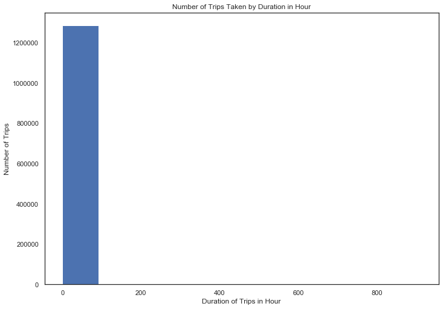

```python
#Plotting histogram for duration_hour
plt.figure(figsize=[ 11.69, 8.27])
plt.hist(data = df, x = 'duration_hour')
plt.xlabel('Duration of Trips in Hour',fontsize=12)
plt.ylabel('Number of Trips',fontsize=12)
plt.title('Number of Trips Taken by Duration in Hour',fontsize=12);
```

```python
df.shape
```

```
(1285043, 18)
```

```python
df.query('duration_hour >15000').shape
```

```
(0, 18)
```

> From the above histogram, I notice that majority of the data falls around the value 0 for duration_hour.

```python
#Checking the count of records with duration_hour is 0
df.query('duration_hour == 0').shape[0]
```

```
5095
```

```python
df.query('duration_hour == 0').head()
```

|  | duration_sec | start_time | end_time | start_lat | start_lng | end_lat | end_lng | unique_id | user_type | distance_traveled | duration_hour | start_date | end_date | started_time | ended_time | weekday | start_time_hour | start_month |
| --- | --- | --- | --- | --- | --- | --- | --- | --- | --- | --- | --- | --- | --- | --- | --- | --- | --- | --- |
| 61 | 16 | 2020-04-10 16:24:19 | 2020-04-10 16:24:35 | 37.7603 | -122.5063 | 37.7604 | -122.5063 | 3A6752EC28920DE6 | Customer | 0.01 | 0.0 | 2020-04-10 | 2020-04-10 | 16:24:19 | 16:24:35 | Friday | 16 | Apr |
| 209 | 12 | 2020-04-26 19:33:35 | 2020-04-26 19:33:47 | 37.7605 | -122.3914 | 37.7605 | -122.3914 | 15D59C9E2A510F34 | Customer | 0.00 | 0.0 | 2020-04-26 | 2020-04-26 | 19:33:35 | 19:33:47 | Sunday | 19 | Apr |
| 403 | 1 | 2020-04-05 17:04:42 | 2020-04-05 17:04:43 | 37.7974 | -122.3984 | 37.7974 | -122.3985 | 4B6889A1C2E9B971 | Customer | 0.01 | 0.0 | 2020-04-05 | 2020-04-05 | 17:04:42 | 17:04:43 | Sunday | 17 | Apr |
| 432 | 18 | 2020-04-06 13:58:24 | 2020-04-06 13:58:42 | 37.7738 | -122.3913 | 37.7737 | -122.3913 | 1309D99F6AE2FCC5 | Customer | 0.01 | 0.0 | 2020-04-06 | 2020-04-06 | 13:58:24 | 13:58:42 | Monday | 13 | Apr |
| 451 | 10 | 2020-04-26 11:00:40 | 2020-04-26 11:00:50 | 37.4048 | -121.9315 | 37.4048 | -121.9315 | EDBE8BBC70F0C5FA | Customer | 0.00 | 0.0 | 2020-04-26 | 2020-04-26 | 11:00:40 | 11:00:50 | Sunday | 11 | Apr |

```python
#Filtering out those records with duration_hour that are 0
df = df.query('duration_hour != 0')
```

```python
#Testing if the duration_hour has been filtered out
df.query('duration_hour == 0').shape
```

```
(0, 18)
```

```python
#Checking the minimum duration traveled in the dataframe
df['duration_hour'].min()
```

```
-0.23
```

```python
df.query('duration_sec < 0').head()
```

|  | duration_sec | start_time | end_time | start_lat | start_lng | end_lat | end_lng | unique_id | user_type | distance_traveled | duration_hour | start_date | end_date | started_time | ended_time | weekday | start_time_hour | start_month |
| --- | --- | --- | --- | --- | --- | --- | --- | --- | --- | --- | --- | --- | --- | --- | --- | --- | --- | --- |
| 36591 | -20 | 2020-04-29 15:41:36 | 2020-04-29 15:41:16 | 37.7692 | -122.4338 | 37.7592 | -122.4099 | D0C004626C9BABED | Subscriber | 2.38 | -0.01 | 2020-04-29 | 2020-04-29 | 15:41:36 | 15:41:16 | Wednesday | 15 | Apr |
| 39066 | -32 | 2020-04-14 16:59:14 | 2020-04-14 16:58:42 | 37.7896 | -122.4008 | 37.7954 | -122.4048 | 6FFDED24B9616146 | Subscriber | 0.73 | -0.01 | 2020-04-14 | 2020-04-14 | 16:59:14 | 16:58:42 | Tuesday | 16 | Apr |
| 40130 | -74 | 2020-04-29 15:53:47 | 2020-04-29 15:52:33 | 37.8395 | -122.2987 | 37.8395 | -122.2987 | BD57BDA5D174F94E | Customer | 0.00 | -0.02 | 2020-04-29 | 2020-04-29 | 15:53:47 | 15:52:33 | Wednesday | 15 | Apr |
| 40385 | -69 | 2020-04-29 15:53:47 | 2020-04-29 15:52:38 | 37.8395 | -122.2987 | 37.8395 | -122.2987 | 5CC4C14C1D5D6FD2 | Customer | 0.00 | -0.02 | 2020-04-29 | 2020-04-29 | 15:53:47 | 15:52:38 | Wednesday | 15 | Apr |
| 42600 | -92 | 2020-04-05 12:12:09 | 2020-04-05 12:10:37 | 37.7954 | -122.4048 | 37.7954 | -122.4048 | 4C68EC117C07555A | Subscriber | 0.00 | -0.03 | 2020-04-05 | 2020-04-05 | 12:12:09 | 12:10:37 | Sunday | 12 | Apr |

> There's few records where the duration of the rides taken are negative. This doesn't make sense. Therefore, assuming that those were wrongly input, I will convert them into positive values.

```python
# Converting negative duration_hour and duration_sec to positive
df['duration_sec'] = abs(df['duration_sec'])
df['duration_hour'] = abs(df['duration_hour'])
```

```python
# Testing the above if the negative have been sucessfully converted
df.query('duration_sec < 0').head()
```

|  | duration_sec | start_time | end_time | start_lat | start_lng | end_lat | end_lng | unique_id | user_type | distance_traveled | duration_hour | start_date | end_date | started_time | ended_time | weekday | start_time_hour | start_month |
| --- | --- | --- | --- | --- | --- | --- | --- | --- | --- | --- | --- | --- | --- | --- | --- | --- | --- | --- |

```python
df.query('duration_hour < 0')
```

|  | duration_sec | start_time | end_time | start_lat | start_lng | end_lat | end_lng | unique_id | user_type | distance_traveled | duration_hour | start_date | end_date | started_time | ended_time | weekday | start_time_hour | start_month |
| --- | --- | --- | --- | --- | --- | --- | --- | --- | --- | --- | --- | --- | --- | --- | --- | --- | --- | --- |

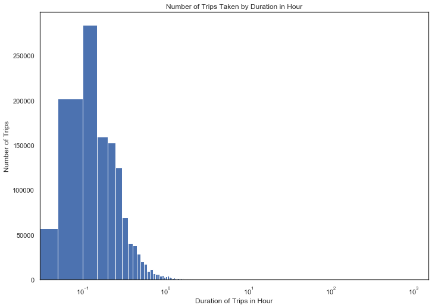

```python
#Univariate exploration for the variable duration_hour after the first failed attempt
# Using bin size for "df"
log_binsize = 0.05
bins = np.arange(0, df['duration_hour'].max()+log_binsize, log_binsize)

plt.figure(figsize=[ 11.69, 8.27])
plt.hist(data = df, x = 'duration_hour', bins = bins)
plt.xscale('log')
plt.xlabel('Duration of Trips in Hour',fontsize=12)
plt.ylabel('Number of Trips',fontsize=12)
plt.title('Number of Trips Taken by Duration in Hour',fontsize=12)
plt.show()
```

> Although not easy to interprete, I can see that majority of bike duration is around 0.1 to 0.3 hours.

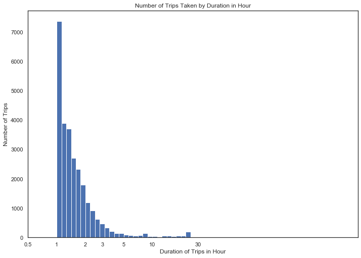

```python
# Let's transform the duration_hour of dataframe 'df'
log_binsize = 0.05
bins = 10 ** np.arange(0, np.log10(df['duration_hour'].max())+log_binsize, log_binsize)

plt.figure(figsize=[ 11.69, 8.27])
plt.hist(data = df, x = 'duration_hour', bins = bins)
plt.xscale('log')
plt.xticks([0.5, 1, 2, 3, 5, 10, 30],[0.5, 1, 2, 3, 5, 10, 30])
plt.xlabel('Duration of Trips in Hour',fontsize=12)
plt.ylabel('Number of Trips',fontsize=12)
plt.title('Number of Trips Taken by Duration in Hour',fontsize=12)
plt.show();
```

> From the above plot, the distribution looks unimodal where most of the data falls on 1.

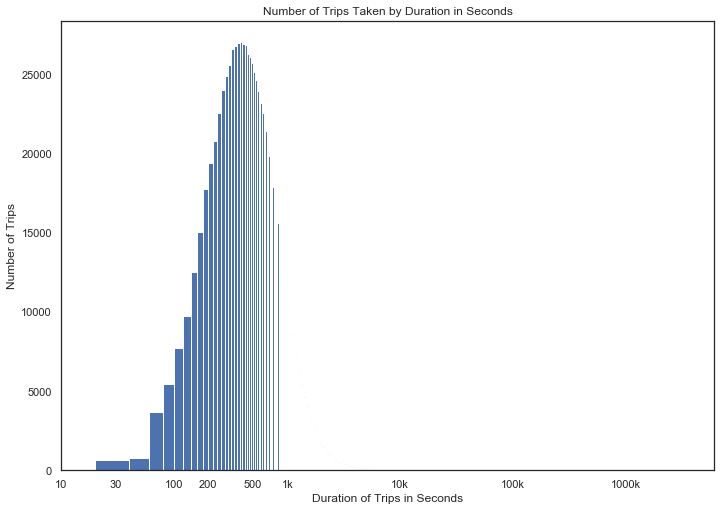

```python
#Univariate exploration for the variable duration_sec
# Using bin size for "df"
log_binsize = 20
bins = np.arange(0, df['duration_sec'].max()+log_binsize, log_binsize)

plt.figure(figsize=[ 11.69, 8.27])
plt.hist(data = df, x = 'duration_sec', bins = bins)
plt.xscale('log')
plt.xticks([10, 30, 100, 200, 500, 1e3, 1e4, 1e5, 1e6],[10, 30, 100, 200, 500, '1k', '10k', '100k', '1000k'])
plt.xlabel('Duration of Trips in Seconds',fontsize=12)
plt.ylabel('Number of Trips',fontsize=12)
plt.title('Number of Trips Taken by Duration in Seconds',fontsize=12)
plt.show()
```

> As seen from the above chart, the duration_secs is a much better alternative to duration_hour to know the distribution of time taken for each bike rides. The peak of the distribution is around 500 secs. It means that most of the bike rides were taken for around 500 secs i.e 8 minutes.

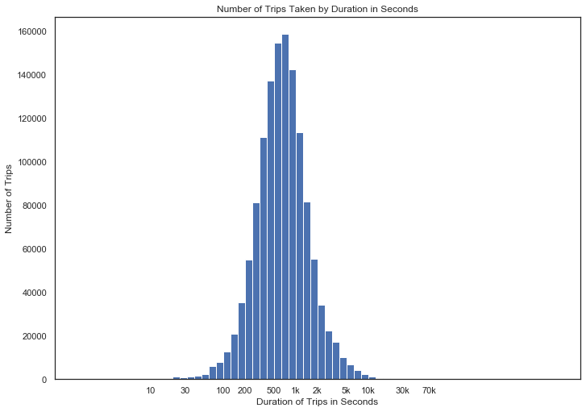

```python
# Let's transform the duration_sec of dataframe 'df'
log_binsize = 0.1
bins = 10 ** np.arange(0, np.log10(df['duration_sec'].max())+log_binsize, log_binsize)

plt.figure(figsize=[ 11.69, 8.27])
plt.hist(data = df, x = 'duration_sec', bins = bins)
plt.xscale('log')
plt.xticks([10, 30, 100, 200, 500, 1e3, 2e3, 5e3, 10e3, 30e3, 70e3],[10, 30, 100, 200, 500, '1k', '2k', '5k', '10k','30k','70k'])
plt.xlabel('Duration of Trips in Seconds',fontsize=12)
plt.ylabel('Number of Trips',fontsize=12)
plt.title('Number of Trips Taken by Duration in Seconds',fontsize=12)
plt.show()
```

> As can be seen from the above plot, highest peak falls in the bin between 500-1k bin. The distribution is very similar without log transformation. I think there wasn't any need for a log transformation.

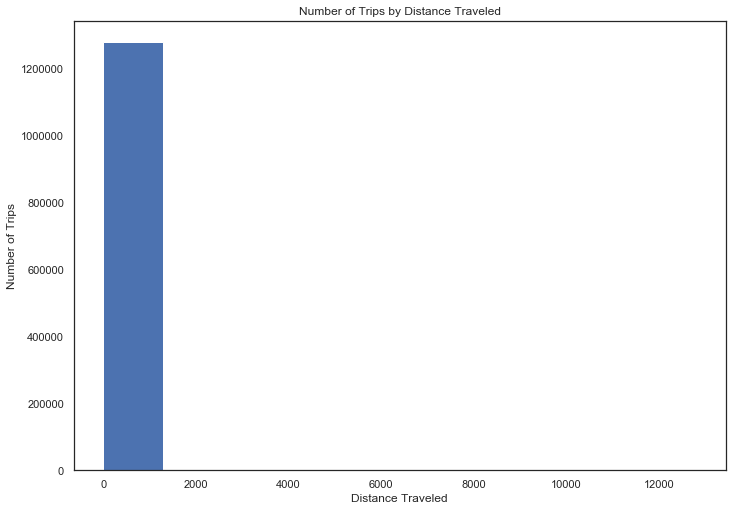

```python
#Plotting histogram for distance_traveled for "df"
plt.figure(figsize=[ 11.69, 8.27])
plt.hist(data = df, x = 'distance_traveled')
plt.xlabel('Distance Traveled',fontsize=12)
plt.ylabel('Number of Trips',fontsize=12)
plt.title('Number of Trips by Distance Traveled',fontsize=12);
```

> The above plot shows that majority of distance traveled are also around the value of 0.

```python
#Checking the count of records with 0 distance traveled
df.query('distance_traveled == 0').shape[0]
```

```
53635
```

```python
df.query('distance_traveled == 0 & duration_sec != 0').head()
```

|  | duration_sec | start_time | end_time | start_lat | start_lng | end_lat | end_lng | unique_id | user_type | distance_traveled | duration_hour | start_date | end_date | started_time | ended_time | weekday | start_time_hour | start_month |
| --- | --- | --- | --- | --- | --- | --- | --- | --- | --- | --- | --- | --- | --- | --- | --- | --- | --- | --- |
| 0 | 83118 | 2020-01-31 15:23:47.733 | 2020-02-01 14:29:06.263 | 37.804272 | -122.433537 | 37.804272 | -122.433537 | 13052 | Customer | 0.0 | 23.09 | 2020-01-31 | 2020-02-01 | 15:23:47.733000 | 14:29:06.263000 | Friday | 15 | Jan |
| 1 | 68239 | 2020-01-31 15:40:31.616 | 2020-02-01 10:37:51.000 | 37.767037 | -122.415443 | 37.767037 | -122.415443 | 12235 | Subscriber | 0.0 | 18.96 | 2020-01-31 | 2020-02-01 | 15:40:31.616000 | 10:37:51 | Friday | 15 | Jan |
| 2 | 55407 | 2020-01-31 17:48:16.635 | 2020-02-01 09:11:44.317 | 37.808848 | -122.249680 | 37.808848 | -122.249680 | 12822 | Customer | 0.0 | 15.39 | 2020-01-31 | 2020-02-01 | 17:48:16.635000 | 09:11:44.317000 | Friday | 17 | Jan |
| 3 | 54929 | 2020-01-31 17:53:03.413 | 2020-02-01 09:08:32.634 | 37.808848 | -122.249680 | 37.808848 | -122.249680 | 11705 | Customer | 0.0 | 15.26 | 2020-01-31 | 2020-02-01 | 17:53:03.413000 | 09:08:32.634000 | Friday | 17 | Jan |
| 7 | 4038 | 2020-01-31 23:32:03.907 | 2020-02-01 00:39:22.021 | 37.763934 | -122.470651 | 37.763934 | -122.470651 | 1589 | Customer | 0.0 | 1.12 | 2020-01-31 | 2020-02-01 | 23:32:03.907000 | 00:39:22.021000 | Friday | 23 | Jan |

> From the above analysis, I can see that there are several records have 0 distance traveled but have duration of the bike rides that are greater than 0 secs. Since these do not make sense, they will be removed from the dataframe.

```python
#Filtering out those records with distance traveled 0
df = df.query('distance_traveled != 0')
```

```python
#Testing if the above filters has been executed successfully
df.query('distance_traveled == 0 & duration_sec != 0').shape
```

```
(0, 18)
```

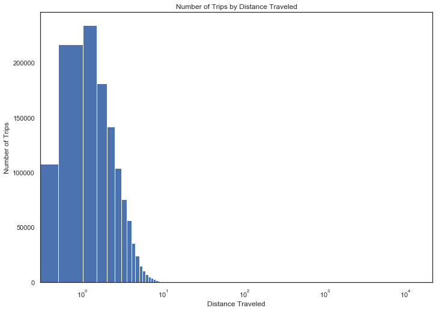

```python
#Plotting histogram using bin size
binsize = 0.5
bins = np.arange(0, df['distance_traveled'].max()+binsize, binsize)

plt.figure(figsize=[ 11.69, 8.27])
plt.hist(data = df, x = 'distance_traveled', bins = bins)
plt.xscale('log')
plt.xlabel('Distance Traveled',fontsize=12)
plt.ylabel('Number of Trips',fontsize=12)
plt.title('Number of Trips by Distance Traveled',fontsize=12)
plt.show();
```

> From the plot, it can be seen that highest peak is between 1 to 1.5 km. This can imply that majority of the bike rides are of short distance.

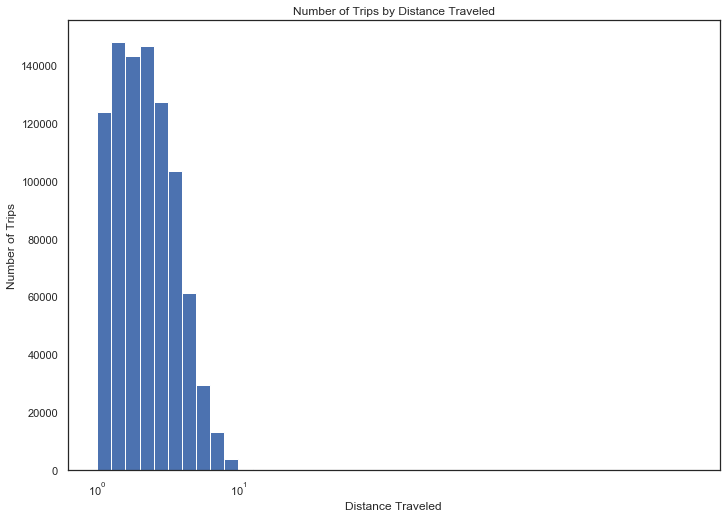

```python
# Let's transform the distance_traveled of dataframe 'df'
log_binsize = 0.10
bins = 10 ** np.arange(0, np.log10(df['distance_traveled'].max())+log_binsize, log_binsize)

plt.figure(figsize=[ 11.69, 8.27])
plt.hist(data = df, x = 'distance_traveled', bins = bins)
plt.xscale('log')
plt.xticks([1, 2, 3, 4, 5, 6, 7, 8, 9, 10])
plt.xlabel('Distance Traveled',fontsize=12)
plt.ylabel('Number of Trips',fontsize=12)
plt.title('Number of Trips by Distance Traveled',fontsize=12)
plt.show()
```

> The above plot has peaks across several bins but it can be seen that highest peak is around 1.5.

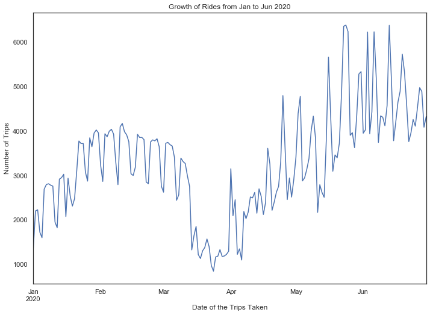

```python
#Plotting line chart for start_date
plt.figure(figsize=[ 11.69, 8.27])
df.groupby('start_date').unique_id.nunique().plot()
plt.xlabel('Date of the Trips Taken',fontsize=12)
plt.ylabel('Number of Trips',fontsize=12)
plt.title('Growth of Rides from Jan to Jun 2020',fontsize=12);
```

> From the above line, it can be seen that there is an increasing trends in the number of trips from Jan 2020 to Jun 2020.

```python
#Counting highest unique users by dates
df_group = df.groupby('start_date').unique_id.nunique()
df_group = df_group.head(10).sort_values(ascending = False)
df_group.head()
```

```
start_date
2020-01-08    2816
2020-01-07    2798
2020-01-09    2784
2020-01-10    2762
2020-01-06    2695
Name: unique_id, dtype: int64
```

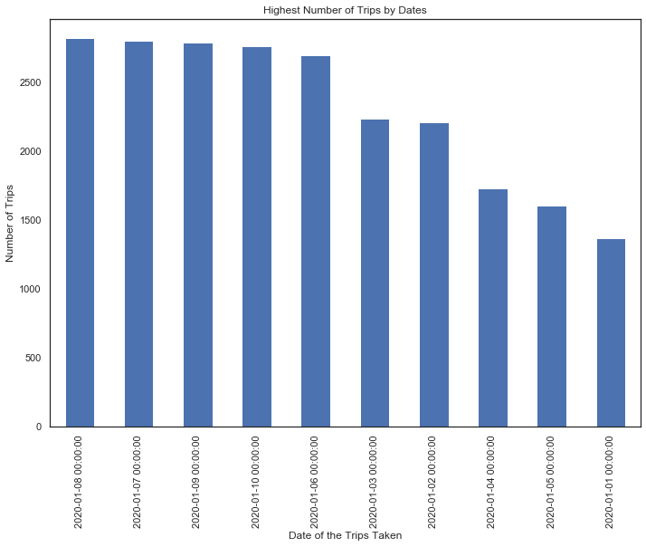

```python
#Plotting bar graph
plt.figure(figsize=[ 11.69, 8.27])
df_group.sort_values(ascending = False).plot.bar(x="start_date", title="Highest Number of Trips by Dates")
plt.xlabel('Date of the Trips Taken',fontsize=12)
plt.ylabel('Number of Trips',fontsize=12);
```

```python
#Counting lowest unique users by dates
df_Subs = df.groupby('start_date').unique_id.nunique()
df_Subs = df_Subs.tail(10).sort_values()
df_Subs.head()
```

```
start_date
2020-06-22    3763
2020-06-23    3962
2020-06-29    4087
2020-06-25    4111
2020-06-24    4259
Name: unique_id, dtype: int64
```

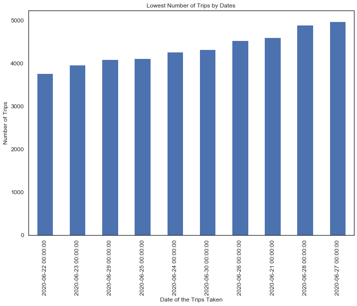

```python
#Plotting bar graph
plt.figure(figsize=[ 11.69, 8.27])
df_Subs.sort_values(ascending = True).plot.bar(x="start_date", title="Lowest Number of Trips by Dates",fontsize=12)
plt.xlabel('Date of the Trips Taken',fontsize=12)
plt.ylabel('Number of Trips',fontsize=12);
```

> From the above bar chart, it can be seen that the lowest number of bike rides were taken on June 22 followed by June 23.

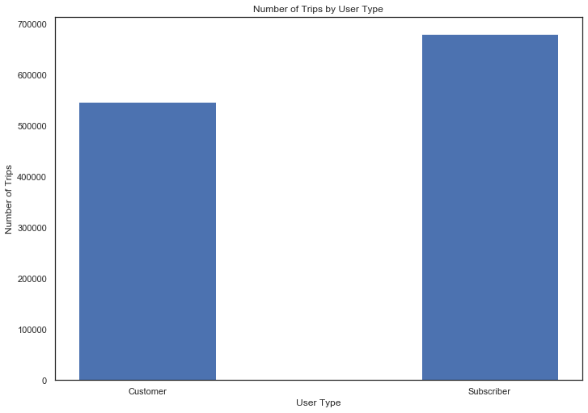

```python
# Creating a bar graph to explore the variable 'user_type'
x = df['user_type'].unique()

# Return the Series having frequency count of each unique value
y = df['user_type'].value_counts(sort=False)

plt.figure(figsize=[ 11.69, 8.27])
plt.bar(x, y,width=0.4,align='center')
plt.xlabel('User Type',fontsize=12)
plt.ylabel('Number of Trips',fontsize=12)
plt.title('Number of Trips by User Type',fontsize=12)

# Dsiplay the plot
plt.show()
```

> From the above bar graph, it can be seen that interms of number of trips by User Type, Subscribers have higher number of trips compared to Customers.

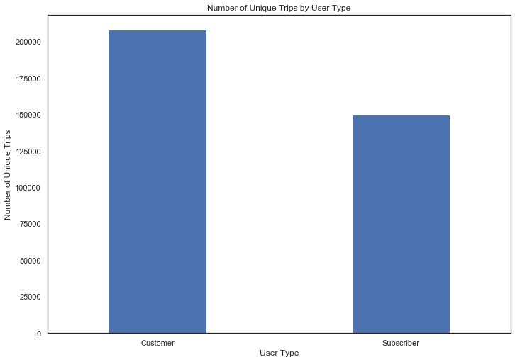

```python
#Creating a bar chart to look into the variable "user_type"
plt.figure(figsize=[ 11.69, 8.27])

df.groupby(['user_type'])['unique_id'].nunique().plot(kind='bar',width=0.4)
plt.xticks(rotation=0)
plt.title('Number of Unique Trips by User Type',fontsize=12)
plt.xlabel('User Type',fontsize=12)
plt.ylabel('Number of Unique Trips',fontsize=12);
```

> However interms of number of unique trips, Customers have higher number of unique trips compared to Subscribers.

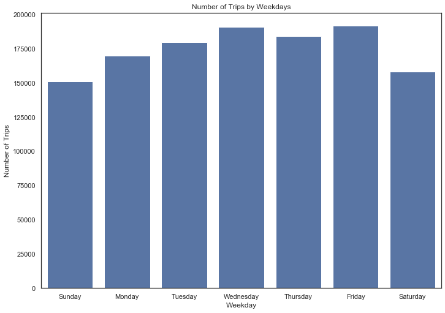

```python
#Creating a bar chart to explore variable "weekday"
weekday_ord = ["Sunday","Monday","Tuesday","Wednesday","Thursday","Friday","Saturday"]
plt.figure(figsize=[ 11.69, 8.27])
x = df['weekday'].unique()

# Return the Series having frequency count of each unique value
y = df['weekday'].value_counts()

base_color = sb.color_palette()[0]

sb.countplot(data=df, x='weekday', color=base_color, order=weekday_ord);

plt.xlabel('Weekday',fontsize=12)
plt.ylabel('Number of Trips',fontsize=12)
plt.title('Number of Trips by Weekdays',fontsize=12)

# Display the plot
plt.show()
```

> From the above bar chart, it can be seen that the busiest days are on Fridays and Wednesdays.

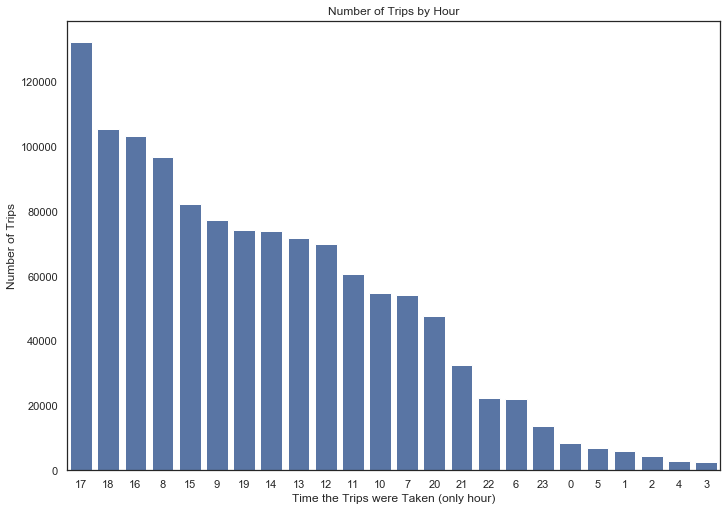

```python
#Creating a bar chart to explore variable "start_hour"
plt.figure(figsize=[ 11.69, 8.27])
x = df['start_time_hour'].unique()

# Return the Series having frequency count of each unique value
y = df['start_time_hour'].value_counts()

gen_order = y.index
base_color = sb.color_palette()[0]

sb.countplot(data=df, x='start_time_hour', color=base_color, order=gen_order);

plt.xlabel('Time the Trips were Taken (only hour)',fontsize=12)
plt.ylabel('Number of Trips',fontsize=12)
plt.title('Number of Trips by Hour',fontsize=12)

# Display the plot
plt.show()
```

> The busiest times are on 5pm, 6pm and 4pm.

### Discuss the distribution(s) of your variable(s) of interest. Were there any unusual points? Did you need to perform any transformations?

> I used univariate exploratory analysis for most of the variables that have been identified as the variables that will best describe the behaviour of the user type. There were lot of unusual points that were identified as I did the univariate analysis. These unusual points were further investigated and filtered/removed. I did perform log transformation for duration_hour, duration_sec and distance_traveled, although in some instance it seemed unnecessary.  
> With regards to start_date, the highest no. of unique users was on Jan 8, 2020 whereas the lowest no. of unique users was on June 22, 2020.  
> Susbcribers were seen to take more rides than customers however, there were more unique rides taken by customers than subscribers.  
> The busiest days are on Fridays and Wednesdays and on 5pm, 6pm and 4pm.

### Of the features you investigated, were there any unusual distributions? Did you perform any operations on the data to tidy, adjust, or change the form of the data? If so, why did you do this?

> When investigating duration_hour and duration_secs, some datasets were found to be negative. These values were converted into positive assuming that the "-ve" signs were incorrectly input. Also while investigating the distance_traveled, I found few records that had 0 distance traveled however, the duration taken was more than 0 secs. These were filtered out from the dataframe.

## Bivariate Exploration

> We will now begin with our bivariate exploration to understand our main interest i.e. the behaviour of the subscriber and customer using the app. Let's try to find the relationship between start dates and unique id.

> Outlining the variables that will be analysed:  
> numeric_vars = 'duration_sec', 'distance_traveled', 'start_time_hour'  
> categoric_vars = 'weekday', 'user_type', 'start_month'

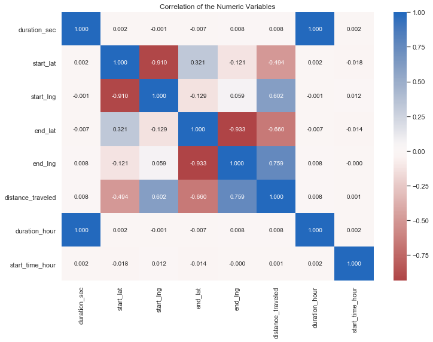

```python
#Analysing the correlation among the variables
plt.figure(figsize=[ 11.69, 8.27])
sb.heatmap(df.corr(), annot = True, fmt = '.3f',
           cmap = 'vlag_r', center = 0)
plt.title('Correlation of the Numeric Variables',fontsize=12)
plt.show();
```

> From the above heatmaps, I am not able to draw any suggestion/conclusion.

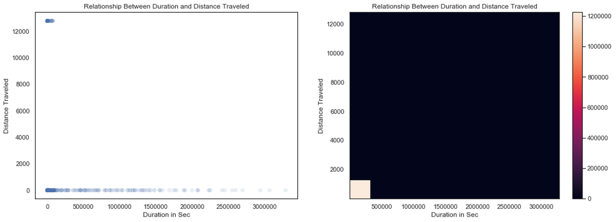

```python
#Looking into the relationship between "duration" and "distance traveled"
plt.figure(figsize = [18, 6])

# PLOT ON LEFT
plt.subplot(1, 2, 1)
sb.regplot(data = df, x = 'duration_sec', y = 'distance_traveled', x_jitter=0.04, scatter_kws={'alpha':1/10}, fit_reg=False)
plt.xlabel('Duration in Sec',fontsize=12)
plt.ylabel('Distance Traveled',fontsize=12)
plt.title('Relationship Between Duration and Distance Traveled',fontsize=12);

# PLOT ON RIGHT
plt.subplot(1, 2, 2)
plt.hist2d(data = df, x = 'duration_sec', y = 'distance_traveled')
plt.colorbar()
plt.xlabel('Duration in Sec',fontsize=12)
plt.ylabel('Distance Traveled',fontsize=12)
plt.title('Relationship Between Duration and Distance Traveled',fontsize=12);
```

> From the above two different charts, I will choose the scatter plot to further deep dive into the data to analyse the relationship. The above scatter plot shows that there are few outliers. These will be removed so that the trends can be better analysed.

```python
#Removing the outliers based on the above scatter plot
df_new = df.query('distance_traveled < 30 & duration_sec < 250000')
```

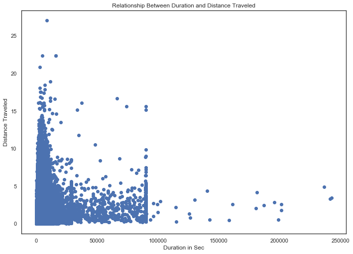

```python
plt.figure(figsize=[ 11.69, 8.27])
plt.scatter(data = df_new, x = 'duration_sec', y = 'distance_traveled')
plt.xlabel('Duration in Sec',fontsize=12)
plt.ylabel('Distance Traveled',fontsize=12)
plt.title('Relationship Between Duration and Distance Traveled',fontsize=12);
```

> After clearing out the outliers, the trends seems to be clearer for those areas that have the majority of the data. However, I would like to further drill to the higher traffic areas.

```python
#Removing the outliers based on the above scatter plot
df_new = df.query('distance_traveled < 20 & duration_sec < 100000')
```

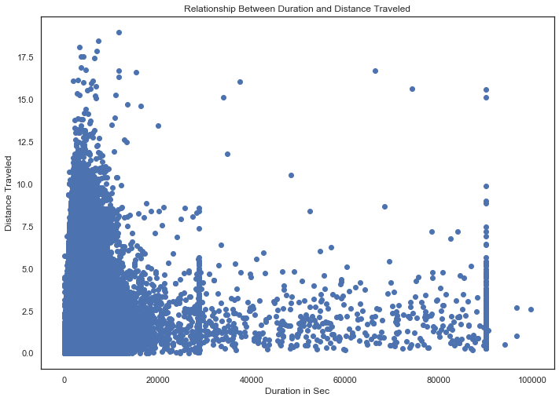

```python
plt.figure(figsize=[ 11.69, 8.27])
plt.scatter(data = df_new, x = 'duration_sec', y = 'distance_traveled')
plt.xlabel('Duration in Sec',fontsize=12)
plt.ylabel('Distance Traveled',fontsize=12)
plt.title('Relationship Between Duration and Distance Traveled',fontsize=12);
```

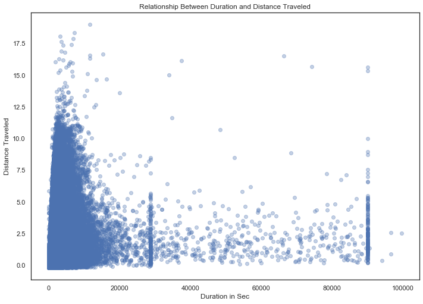

```python
#Adding jitters by using regplot
plt.figure(figsize=[ 11.69, 8.27])
sb.regplot(data = df_new, x = 'duration_sec', y = 'distance_traveled', fit_reg = False,
           x_jitter = 0.2, y_jitter = 0.2, scatter_kws = {'alpha' : 1/3})
plt.xlabel('Duration in Sec',fontsize=12)
plt.ylabel('Distance Traveled',fontsize=12)
plt.title('Relationship Between Duration and Distance Traveled',fontsize=12);
```

> From the above scatter plot it can be said that, majority of the bike rides taken by the app's subscribers had duration of less than 20,000 secs (5.55 hrs) and distance traveled of less than 12km.

Placing the above scatter plot for df_Subscriber and df_Customer side by side for easier analysis.

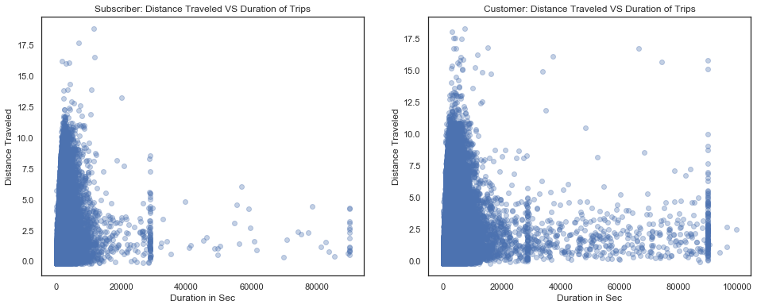

```python
plt.figure(figsize = [16, 6])

# left plot: scatterplot of discrete data with jitter and transparency for df_Subscriber
plt.subplot(1, 2, 1)
sb.regplot(data = df_new.query('user_type == "Subscriber"'), x = 'duration_sec', y = 'distance_traveled', fit_reg = False,
           x_jitter = 0.2, y_jitter = 0.2, scatter_kws = {'alpha' : 1/3})
plt.title("Subscriber: Distance Traveled VS Duration of Trips",fontsize=12)
plt.xlabel('Duration in Sec',fontsize=12)
plt.ylabel('Distance Traveled',fontsize=12);

# right plot: scatterplot of discrete data with jitter and transparency for df_Customer
plt.subplot(1, 2, 2)
sb.regplot(data = df_new.query('user_type == "Customer"'), x = 'duration_sec', y = 'distance_traveled', fit_reg = False,
           x_jitter = 0.2, y_jitter = 0.2, scatter_kws = {'alpha' : 1/3})
plt.title("Customer: Distance Traveled VS Duration of Trips",fontsize=12)
plt.xlabel('Duration in Sec',fontsize=12)
plt.ylabel('Distance Traveled',fontsize=12);
```

From the above side by side comparison analysis, it can be noted that user type that are "Customer" use the bike riding service longer than "Subscriber" to travel approximately equivalent distance.

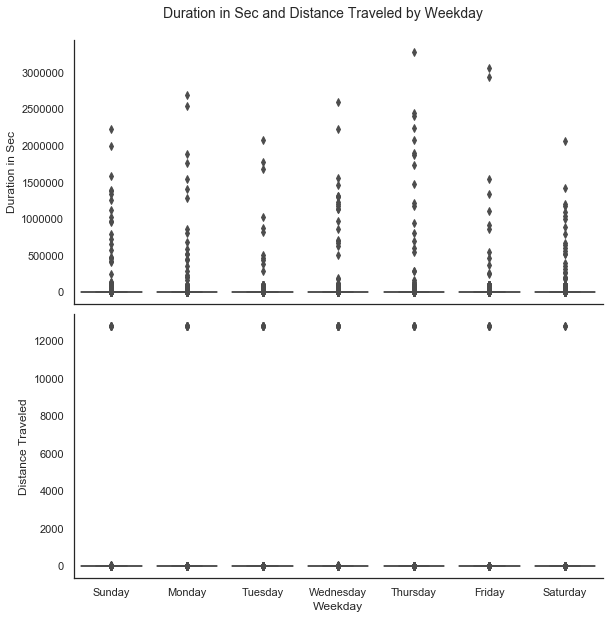

```python
#Analysing the relationship between "weekday" and "duration_sec" and "distance_traveled"
sb.set()
sb.set_style(style='white')
def boxgrid(x, y, **kwargs):
    """ Quick hack for creating box plots with seaborn's PairGrid. """
    default_color = sb.color_palette()[0]
    sb.boxplot(x, y, color = default_color, order= weekday_ord)

g = sb.PairGrid(data = df, y_vars = ['duration_sec', 'distance_traveled'], x_vars = 'weekday',
                height = 4,aspect = 2)
g.map(boxgrid)
g.fig.suptitle('Duration in Sec and Distance Traveled by Weekday', y=1.05,fontsize=14)
g.axes[0,0].set_ylabel('Duration in Sec')
g.axes[1,0].set_ylabel('Distance Traveled')
g.axes[1,0].set_xlabel('Weekday')
plt.show();
```

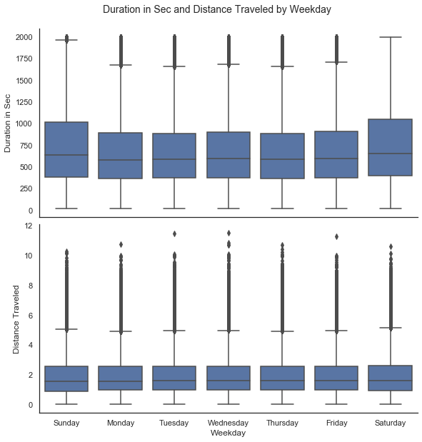

```python
#Filtering outliers from the dataframe
sb.set()
sb.set_style(style='white')
def boxgrid(x, y, **kwargs):
    """ Quick hack for creating box plots with seaborn's PairGrid. """
    default_color = sb.color_palette()[0]
    sb.boxplot(x, y, color = default_color, order= weekday_ord)

g = sb.PairGrid(data = df.query('duration_sec <2000 & distance_traveled < 15'), y_vars = ['duration_sec', 'distance_traveled'], x_vars = 'weekday',
                height = 4,aspect = 2)
g.map(boxgrid)
g.fig.suptitle('Duration in Sec and Distance Traveled by Weekday', y=1.05,fontsize=14)
g.axes[0,0].set_ylabel('Duration in Sec')
g.axes[1,0].set_ylabel('Distance Traveled')
g.axes[1,0].set_xlabel('Weekday')
plt.show();
```

> From the above box plot, I notice an interesting observation. Although, most of the days have pretty similar averages for distance traveled and duration of trips, however, for weekends, for the same length of distance, trips on Saturday and Sunday take longer.

### Talk about some of the relationships you observed in this part of the investigation. How did the feature(s) of interest vary with other features in the dataset?

> What I can suggest after having gone through the above bivariate exploratory analysis is that a large percentage of the Subscribers cover the distance from 0 to 11 km that takes them around 5.5hrs where as for customers, it is largely spread from 0 to 15 km that takes them around 13hrs. Could this be that "Subscribers" using the bikes are healthier and more practised in general thereby taking lesser time than Customers?  
> Another interesting observation is that for the same length of distance traveled, trips on Saturday and Sunday take longer. This will be further looked into by adding another variable "user type".

### Did you observe any interesting relationships between the other features (not the main feature(s) of interest)?

> No other variables apart from the user_type, weekdays and two numeric variables were looked into.  
> Another interesting relationships that was looked into was the only two numeric variables present in the data - duration_sec and distance_traveled. These two variables had weak relationships although it is normally assumed that a larger distance takes longer time to cover.

## Multivariate Exploration

> We will now being to look into our multivariate exploration.

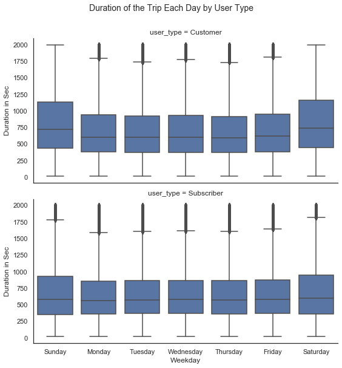

```python
#Analysing the relationship between "user_type", "weekday" and "duration_sec" variables
sb.set()
sb.set_style(style='white')
g = sb.FacetGrid(data = df.query('duration_sec < 2000 & distance_traveled < 15'), col = 'user_type',col_wrap=1, height = 4, aspect= 2)
g.map_dataframe(sb.boxplot, 'weekday', 'duration_sec', order= weekday_ord)
g.fig.suptitle('Duration of the Trip Each Day by User Type', y=1.05,fontsize=14)
g.set_xlabels("Weekday")
g.set_ylabels("Duration in Sec");
```

> The above box plot confirms our bivariate finding. Subscribers are seen to have shorter duration of the trips that they take. Saturday and Sunday have longer trips for both Customers and Subscribers.

[figure not shown]

```python
#Analysing the relationship between "user_type", "weekday" and "distance traveled" variables
sb.set()
sb.set_style(style='white')
g = sb.FacetGrid(data = df.query('duration_sec < 2000 & distance_traveled < 15'), col = 'user_type',col_wrap=1, height = 4, aspect= 2)
g.map(sb.boxplot, 'weekday', 'distance_traveled', order= weekday_ord)
g.fig.suptitle('Distance Traveled Each Day by User Type', y=1.05,fontsize=14)
g.set_xlabels("Weekday")
g.set_ylabels("Distance Traveled");
```

> The distance traveled on most of the days are similar for both Subscribers and Customers.

```python
#Creating two dataframes for Subscribers and Customers
df_Subscriber = df.query('user_type == "Subscriber"')
df_Customer = df.query('user_type == "Customer"')
```

```python
#Creating a pivot table to create a heatmap
pivot = pd.pivot_table(df_Subscriber, values = ['duration_sec'], index = ['weekday'], columns=['start_time_hour'], aggfunc=np.mean).round()
pivot.columns = pivot.columns.droplevel(0)
pivot = pivot.reindex(index=weekday_ord)
pivot
```

| start_time_hour weekday | 0 | 1 | 2 | 3 | 4 | 5 | 6 | 7 | 8 | 9 | ... | 14 | 15 | 16 | 17 | 18 | 19 | 20 | 21 | 22 | 23 |
| --- | --- | --- | --- | --- | --- | --- | --- | --- | --- | --- | --- | --- | --- | --- | --- | --- | --- | --- | --- | --- | --- |
| Sunday | 683.0 | 840.0 | 849.0 | 826.0 | 822.0 | 773.0 | 672.0 | 711.0 | 709.0 | 783.0 | ... | 989.0 | 1233.0 | 932.0 | 856.0 | 793.0 | 773.0 | 728.0 | 704.0 | 677.0 | 768.0 |
| Monday | 722.0 | 763.0 | 998.0 | 968.0 | 802.0 | 699.0 | 986.0 | 707.0 | 719.0 | 675.0 | ... | 810.0 | 807.0 | 776.0 | 788.0 | 750.0 | 729.0 | 693.0 | 682.0 | 713.0 | 703.0 |
| Tuesday | 794.0 | 737.0 | 818.0 | 941.0 | 775.0 | 637.0 | 619.0 | 709.0 | 720.0 | 713.0 | ... | 769.0 | 775.0 | 783.0 | 788.0 | 797.0 | 751.0 | 701.0 | 655.0 | 716.0 | 707.0 |
| Wednesday | 810.0 | 771.0 | 773.0 | 827.0 | 6296.0 | 672.0 | 636.0 | 730.0 | 729.0 | 670.0 | ... | 814.0 | 794.0 | 898.0 | 791.0 | 906.0 | 752.0 | 708.0 | 695.0 | 701.0 | 679.0 |
| Thursday | 701.0 | 887.0 | 868.0 | 845.0 | 811.0 | 649.0 | 666.0 | 710.0 | 725.0 | 671.0 | ... | 801.0 | 774.0 | 886.0 | 782.0 | 784.0 | 731.0 | 692.0 | 708.0 | 716.0 | 710.0 |
| Friday | 714.0 | 955.0 | 873.0 | 901.0 | 939.0 | 779.0 | 707.0 | 742.0 | 733.0 | 747.0 | ... | 825.0 | 808.0 | 797.0 | 820.0 | 799.0 | 766.0 | 742.0 | 748.0 | 729.0 | 745.0 |
| Saturday | 704.0 | 800.0 | 825.0 | 918.0 | 841.0 | 889.0 | 638.0 | 730.0 | 747.0 | 801.0 | ... | 1017.0 | 977.0 | 930.0 | 892.0 | 808.0 | 788.0 | 765.0 | 759.0 | 737.0 | 824.0 |

7 rows × 24 columns

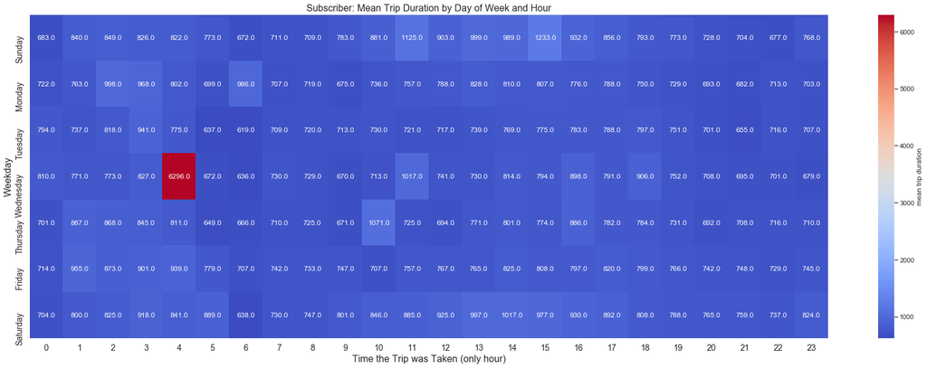

```python
#Heat map of the average duration by day of week and hour taken by Subscribers
plt.figure(figsize=(30,10))
res = sb.heatmap(pivot, annot=True, fmt = '.1f',cbar_kws = {'label' : 'mean trip duration'}, cmap='coolwarm')
plt.title('Subscriber: Mean Trip Duration by Day of Week and Hour',fontsize=16)
plt.xlabel('Time the Trip was Taken (only hour)',fontsize=16)
plt.ylabel('Weekday',fontsize=16)
res.set_xticklabels(res.get_xmajorticklabels(), fontsize = 14)
res.set_yticklabels(res.get_ymajorticklabels(), fontsize = 14);
```

```python
#Creating a pivot table to create a heatmap
pivot = pd.pivot_table(df_Customer, values = ['duration_sec'], index = ['weekday'], columns=['start_time_hour'], aggfunc=np.mean).round()
pivot.columns = pivot.columns.droplevel(0)
pivot = pivot.reindex(index=weekday_ord)
pivot
```

| start_time_hour weekday | 0 | 1 | 2 | 3 | 4 | 5 | 6 | 7 | 8 | 9 | ... | 14 | 15 | 16 | 17 | 18 | 19 | 20 | 21 | 22 | 23 |
| --- | --- | --- | --- | --- | --- | --- | --- | --- | --- | --- | --- | --- | --- | --- | --- | --- | --- | --- | --- | --- | --- |
| Sunday | 1133.0 | 1091.0 | 1781.0 | 10031.0 | 1436.0 | 1121.0 | 5915.0 | 1152.0 | 2254.0 | 1177.0 | ... | 1659.0 | 1639.0 | 1513.0 | 1716.0 | 1565.0 | 1330.0 | 1456.0 | 1659.0 | 2976.0 | 2103.0 |
| Monday | 3462.0 | 2446.0 | 1613.0 | 1296.0 | 894.0 | 887.0 | 2468.0 | 873.0 | 797.0 | 836.0 | ... | 1570.0 | 1892.0 | 1104.0 | 1343.0 | 1424.0 | 906.0 | 949.0 | 922.0 | 1019.0 | 1263.0 |
| Tuesday | 6167.0 | 1243.0 | 1500.0 | 1380.0 | 992.0 | 731.0 | 684.0 | 717.0 | 916.0 | 759.0 | ... | 1210.0 | 1232.0 | 1198.0 | 951.0 | 1194.0 | 991.0 | 1595.0 | 1154.0 | 1250.0 | 975.0 |
| Wednesday | 1212.0 | 1532.0 | 1141.0 | 1258.0 | 892.0 | 1097.0 | 705.0 | 705.0 | 786.0 | 787.0 | ... | 1163.0 | 1943.0 | 1382.0 | 1207.0 | 1537.0 | 1037.0 | 1283.0 | 1837.0 | 1700.0 | 1012.0 |
| Thursday | 2748.0 | 1499.0 | 2702.0 | 1024.0 | 11902.0 | 748.0 | 695.0 | 776.0 | 723.0 | 881.0 | ... | 1243.0 | 1182.0 | 1209.0 | 1150.0 | 1121.0 | 1018.0 | 1797.0 | 950.0 | 2513.0 | 1199.0 |
| Friday | 1289.0 | 1425.0 | 1429.0 | 1697.0 | 1013.0 | 986.0 | 680.0 | 732.0 | 754.0 | 963.0 | ... | 1270.0 | 1210.0 | 1697.0 | 1143.0 | 1417.0 | 1198.0 | 1100.0 | 1693.0 | 908.0 | 951.0 |
| Saturday | 1426.0 | 1110.0 | 1291.0 | 1443.0 | 4164.0 | 1110.0 | 1429.0 | 1059.0 | 2385.0 | 1303.0 | ... | 1799.0 | 1892.0 | 1666.0 | 1340.0 | 1425.0 | 1280.0 | 1998.0 | 1069.0 | 1223.0 | 1061.0 |

7 rows × 24 columns

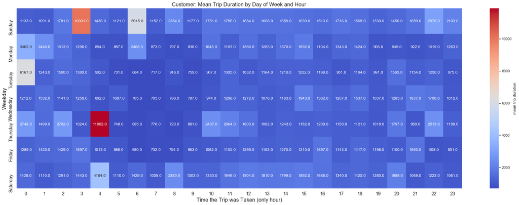

```python
plt.figure(figsize=(30,10))
res = sb.heatmap(pivot, annot=True, fmt = '.1f',cbar_kws = {'label' : 'mean trip duration'}, cmap='coolwarm')
plt.title('Customer: Mean Trip Duration by Day of Week and Hour',fontsize=16)
plt.xlabel('Time the Trip was Taken (only hour)',fontsize=16)
plt.ylabel('Weekday',fontsize=16)
res.set_xticklabels(res.get_xmajorticklabels(), fontsize = 14)
res.set_yticklabels(res.get_ymajorticklabels(), fontsize = 14);
```

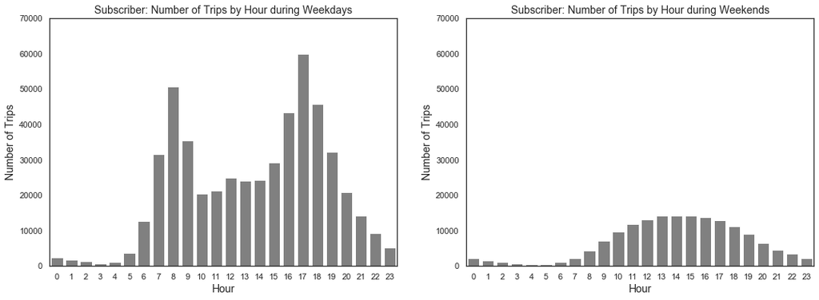

```python
#Looking at the number of trips taken by subscribers in different hours of day during weekdays vs weekends
import seaborn as sns
plt.figure(figsize=(18,6))

plt.subplot(1,2,1)
fig1 = sb.countplot(x= 'start_time_hour', data = df_Subscriber.query('weekday == "Monday" or weekday == "Tuesday" or weekday == "Wednesday" or weekday == "Thursday" or weekday == "Friday"'), color='Grey')
plt.title('Subscriber: Number of Trips by Hour during Weekdays',fontsize=14)
plt.xlabel('Hour',fontsize=14)
plt.ylabel('Number of Trips',fontsize=14)
plt.ylim([0,70000])

plt.subplot(1,2,2)
fig2 = sb.countplot(x='start_time_hour', data = df_Subscriber.query('weekday == "Saturday" or weekday == "Sunday"'), color = 'Grey')
plt.title('Subscriber: Number of Trips by Hour during Weekends',fontsize=14)
plt.xlabel('Hour',fontsize=14)
plt.ylabel('Number of Trips',fontsize=14)
plt.ylim([0,70000]);
```

> From the above charts, it can be seen that Subscribers are most active riding during weekdays compared to weekends and on 8am and and 5pm.

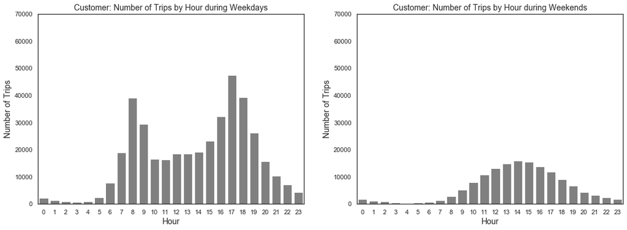

```python
#Looking at the number of trips taken by customers in different hours of day during weekdays vs weekends
plt.figure(figsize=(18,6))

plt.subplot(1,2,1)
fig1 = sb.countplot(x= 'start_time_hour', data = df_Customer.query('weekday == "Monday" or weekday == "Tuesday" or weekday == "Wednesday" or weekday == "Thursday" or weekday == "Friday"'), color='Grey')
plt.title('Customer: Number of Trips by Hour during Weekdays',fontsize=14)
plt.xlabel('Hour',fontsize=14)
plt.ylabel('Number of Trips',fontsize=14)
plt.ylim([0,70000])

plt.subplot(1,2,2)
fig2 = sb.countplot(x='start_time_hour', data = df_Customer.query('weekday == "Saturday" or weekday == "Sunday"'), color = 'Grey')
plt.title('Customer: Number of Trips by Hour during Weekends',fontsize=14)
plt.xlabel('Hour',fontsize=14)
plt.ylabel('Number of Trips',fontsize=14)
plt.ylim([0,70000]);
```

> As for the customers, they are also most active during weekdays and has higher traffic on 8am and 5pm.

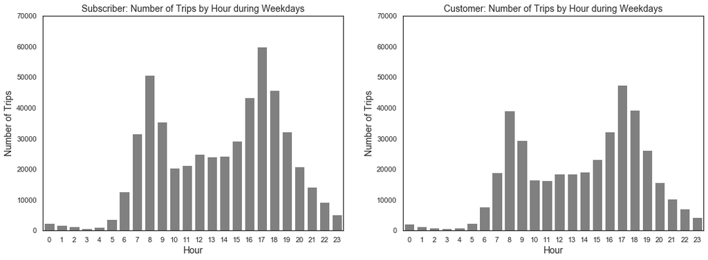

```python
#Side by side comparison of Number of Trips taken by Subscriber and Customer during Weekdays

plt.figure(figsize = [18, 6])

# left plot: scatterplot of discrete data with jitter and transparency for df_Subscriber
plt.subplot(1,2,1)
fig1 = sb.countplot(x= 'start_time_hour', data = df_Subscriber.query('weekday == "Monday" or weekday == "Tuesday" or weekday == "Wednesday" or weekday == "Thursday" or weekday == "Friday"'), color='Grey')
plt.title('Subscriber: Number of Trips by Hour during Weekdays',fontsize=14)
plt.xlabel('Hour',fontsize=14)
plt.ylabel('Number of Trips',fontsize=14)
plt.ylim([0,70000])

# right plot: scatterplot of discrete data with jitter and transparency for df_Customer
plt.subplot(1,2,2)
fig2 = sb.countplot(x= 'start_time_hour', data = df_Customer.query('weekday == "Monday" or weekday == "Tuesday" or weekday == "Wednesday" or weekday == "Thursday" or weekday == "Friday"'), color='Grey')
plt.title('Customer: Number of Trips by Hour during Weekdays',fontsize=14)
plt.xlabel('Hour',fontsize=14)
plt.ylabel('Number of Trips',fontsize=14)
plt.ylim([0,70000]);
```

> The above chart is a side by side comparison of the number of trips taken by Subscriber vs Customer. Although both chart shows the highest rides on 8am and 5pm, Subscribers in general have higher number of rides compared to Customers.

### Summary of the Exploratory Analysis

> DATASET
> - The dataset that I chose was the Ford GoBike System Data.
> - There are 1,285,045 rows in the dataset with 18 columns (duration_sec, start_time, end_time, start_lat, start_lng, end_lat, end_lng, unique_id, unique_id, user_type, distance_traveled, duration_hour, start_date, end_date, started_time, ended_time, weekday, start_time_hour and start_month.
> - The dataset is from the month Jan to Jun of the year 2020.

> SUMMARY of FINDINGS

> Univariate Analysis
> - There were lot of unusual points that were identified as as part of the univariate analysis. These unusual points were further investigated and filtered/removed if it was seen to be helpful. I performed log transformation for duration_hour, duration_sec and distance_traveled, although in some instance it seemed unnecessary.
> - With regards to start_date, the highest no. of unique users was on Jan 8, 2020 whereas the lowest no. of unique users was on June 22, 2020.
> - Subscribers were seen to take more rides than customers however, there were more unique rides taken by customers than subscribers.
> - The busiest days are on Fridays and Wednesdays and on 5pm, 6pm and 4pm.

> Bivariate Analysis
> - What I can suggest after having gone through the above bivariate exploratory analysis is that a large percentage of the Subscribers cover distance from 0 to 11 km that takes them around 5.5hrs where as for customers, it is largely spread from 0 to 15 km that takes them around 13hrs. Could this be that "Subscribers" using the bikes are healthier and more practised in general thereby taking lesser time than Customers?
> - Another interesting observation is that for the same length of distance traveled, trips on Saturday and Sunday take longer.

> KEY INSIGHTS for PRESENTATION

### Reference

> - https://www.w3resource.com/python-exercises/math/python-math-exercise-27.php
> - https://stackoverflow.com/questions/54733465/pandas-how-to-extract-hhmm-from-datetime-column-in-python/54733547
> - https://stackoverflow.com/questions/39850632/pandas-filter-in-rows-that-have-a-null-none-nan-value-in-any-of-several-specifi
> - https://moonbooks.org/Articles/How-to-increase-the-size-of-axes-labels-on-a-seaborn-heatmap-in-python-/